# Project: Investigate Soccer Dataset

- Introduction
- Data Wrangling
- Exploratory Data Analysis
- Conclusions

## Introduction

> This soccer database comes from Kaggle and is well suited for data analysis and machine learning. It contains data for soccer matches, players, and teams from several European countries from 2008 to 2016. The purpose of this kernel is to perform data analytics and visualization of the data from the soccer database: https://www.kaggle.com/hugomathien/soccer. Once completed, a second kernel will be completed in an attempt to predict the winner of soccer games based off the league, teams and results availabe in the data

```python
import numpy as np #
import pandas as pd #
%matplotlib inline
import matplotlib.pyplot as plt
import datetime
import seaborn as sns


# Input data files are available in the "../input/" directory.
# For example, running this (by clicking run or pressing Shift+Enter) will list the files in the input directory
```

## Data Wrangling

### General Properties

```python
#The database was originally in SQL. We installed DB Browser to open the database and import all tables in CSV format.
#after that we start loading the tables into notebook.
player_table = pd.read_csv('player.csv')
player_att_table = pd.read_csv('player_attributes.csv')
match_table = pd.read_csv('match.csv')
league_table = pd.read_csv('league.csv')
country_table = pd.read_csv('country.csv')
team_table = pd.read_csv('team.csv')
team_att_table = pd.read_csv('team_attributes.csv')
```

```python
# check how many tables contains Null values to check the quality of data.
print("Player Table Null Values", player_table.isnull().sum(axis=0))
print(100*'*')
print("Player Attribute Table Null Values", player_att_table.isnull().sum(axis=0))
print(100*'*')
print("Match Table Null Values", match_table.isnull().sum(axis=0))
print(100*'*')
print("League Table Null Values", league_table.isnull().sum(axis=0))
print(100*'*')
print("Country Table Null Values", country_table.isnull().sum(axis=0))
print(100*'*')
print("Team Table Null Values", team_table.isnull().sum(axis=0))
print(100*'*')
print("Team Attribute Table Null Values", team_att_table.isnull().sum(axis=0))
print(100*'*')
```

```
Player Table Null Values id                    0
player_api_id         0
player_name           0
player_fifa_api_id    0
birthday              0
height                0
weight                0
dtype: int64
Player Attribute Table Null Values id                        0
player_fifa_api_id        0
player_api_id             0
date                      0
overall_rating          836
potential               836
preferred_foot          836
attacking_work_rate    3230
defensive_work_rate     836
crossing                836
finishing               836
heading_accuracy        836
short_passing           836
volleys                2713
dribbling               836
curve                  2713
free_kick_accuracy      836
long_passing            836
ball_control            836
acceleration            836
sprint_speed            836
agility                2713
reactions               836
balance                2713
shot_power              836
jumping                2713
stamina                 836
strength                836
long_shots              836
aggression              836
interceptions           836
positioning             836
```

[output cut: 97 more lines]

```
chanceCreationPassing               0
chanceCreationPassingClass          0
chanceCreationCrossing              0
chanceCreationCrossingClass         0
chanceCreationShooting              0
chanceCreationShootingClass         0
chanceCreationPositioningClass      0
defencePressure                     0
defencePressureClass                0
defenceAggression                   0
defenceAggressionClass              0
defenceTeamWidth                    0
defenceTeamWidthClass               0
defenceDefenderLineClass            0
dtype: int64
```

```python
player_att_table.dropna(inplace=True)# dropping the rows with missing data
```

```python
team_att_table.info() # check the quality of data for team attributes and found the column 'buildUpPlayDribbling'
#with missing values. So we fill all the NA values with mean value.

#make a copy of original table and work on copy.
team_att_table2=team_att_table
```

```
<class 'pandas.core.frame.DataFrame'>
RangeIndex: 1458 entries, 0 to 1457
Data columns (total 25 columns):
id                                1458 non-null int64
team_fifa_api_id                  1458 non-null int64
team_api_id                       1458 non-null int64
date                              1458 non-null object
buildUpPlaySpeed                  1458 non-null int64
buildUpPlaySpeedClass             1458 non-null object
buildUpPlayDribbling              489 non-null float64
buildUpPlayDribblingClass         1458 non-null object
buildUpPlayPassing                1458 non-null int64
buildUpPlayPassingClass           1458 non-null object
buildUpPlayPositioningClass       1458 non-null object
chanceCreationPassing             1458 non-null int64
chanceCreationPassingClass        1458 non-null object
chanceCreationCrossing            1458 non-null int64
chanceCreationCrossingClass       1458 non-null object
chanceCreationShooting            1458 non-null int64
chanceCreationShootingClass       1458 non-null object
chanceCreationPositioningClass    1458 non-null object
defencePressure                   1458 non-null int64
defencePressureClass              1458 non-null object
defenceAggression                 1458 non-null int64
defenceAggressionClass            1458 non-null object
defenceTeamWidth                  1458 non-null int64
defenceTeamWidthClass             1458 non-null object
defenceDefenderLineClass          1458 non-null object
dtypes: float64(1), int64(11), object(13)
memory usage: 284.8+ KB
```

```python
#we filled all the missing value with mean value.
team_att_table2['buildUpPlayDribbling'].fillna(team_att_table2['buildUpPlayDribbling'].mean(), inplace=True)
```

```python
#change the data type for buildUpPlayingDribbling from Float to Int
team_att_table2.buildUpPlayDribbling = team_att_table2.buildUpPlayDribbling.astype(int)
```

```python
# Get a Combine Score from MEAN() of all the given scores. Insert a new column with name of combine_score
team_att_table2['combined_score'] = team_att_table2[['buildUpPlaySpeed','buildUpPlayDribbling','buildUpPlayPassing','chanceCreationPassing','chanceCreationCrossing','chanceCreationShooting','defencePressure','defenceAggression','defenceTeamWidth']].mean(axis=1)
team_att_table2

team_att_table.to_csv('team_att2.csv')# save it as CSV for future use.
```

```python
team_att_table2.combined_score = team_att_table2.combined_score.astype(int)
```

```python
team_att_table4=team_att_table2.merge(team_table, how='inner', right_on='team_api_id', left_on='team_api_id')
```

```python
team_name=team_att_table4['team_long_name'].values.tolist();
```

### Data Cleaning

```python
team_att_table4.dropna(inplace=True)# dropping the rows with missing data
```

```python
#change the date column datatype from String to Datetime
team_att_table4['date']=pd.to_datetime(team_att_table['date'])
```

```python
team_att_table4['year'] = pd.to_datetime(team_att_table2['date']).dt.to_period('Y')
team_att_table4.info()#check the datatype now
```

```
<class 'pandas.core.frame.DataFrame'>
Int64Index: 1458 entries, 0 to 1457
Data columns (total 31 columns):
id_x                              1458 non-null int64
team_fifa_api_id_x                1458 non-null int64
team_api_id                       1458 non-null int64
date                              1458 non-null datetime64[ns]
buildUpPlaySpeed                  1458 non-null int64
buildUpPlaySpeedClass             1458 non-null object
buildUpPlayDribbling              1458 non-null int32
buildUpPlayDribblingClass         1458 non-null object
buildUpPlayPassing                1458 non-null int64
buildUpPlayPassingClass           1458 non-null object
buildUpPlayPositioningClass       1458 non-null object
chanceCreationPassing             1458 non-null int64
chanceCreationPassingClass        1458 non-null object
chanceCreationCrossing            1458 non-null int64
chanceCreationCrossingClass       1458 non-null object
chanceCreationShooting            1458 non-null int64
chanceCreationShootingClass       1458 non-null object
chanceCreationPositioningClass    1458 non-null object
defencePressure                   1458 non-null int64
defencePressureClass              1458 non-null object
defenceAggression                 1458 non-null int64
defenceAggressionClass            1458 non-null object
defenceTeamWidth                  1458 non-null int64
defenceTeamWidthClass             1458 non-null object
defenceDefenderLineClass          1458 non-null object
combined_score                    1458 non-null int32
id_y                              1458 non-null int64
team_fifa_api_id_y                1458 non-null float64
team_long_name                    1458 non-null object
team_short_name                   1458 non-null object
year                              1458 non-null period[A-DEC]
dtypes: datetime64[ns](1), float64(1), int32(2), int64(12), object(14), period[A-DEC](1)
memory usage: 353.1+ KB
```

```python
team_table2=team_table

team_att_table4['old_score']=team_att_table4.query('year>=2010' and 'year<2015').combined_score
team_att_table4['new_score']=team_att_table4.query('year==2015').combined_score
#team_table2['new_score']=team_att_table4.query('year==2015').combined_score
table1=team_att_table4.query('year==2010')
table2=team_att_table4.query('year==2015')

table1.drop('new_score', axis=1, inplace=True)
table2.drop('old_score', axis=1, inplace=True)
```

```
C:\Users\Fouzan Saeed\Anaconda3\lib\site-packages\pandas\core\frame.py:3940: SettingWithCopyWarning:
A value is trying to be set on a copy of a slice from a DataFrame

See the caveats in the documentation: http://pandas.pydata.org/pandas-docs/stable/indexing.html#indexing-view-versus-copy
  errors=errors)
```

```python
table1
```

|  | id_x | team_fifa_api_id_x | team_api_id | date | buildUpPlaySpeed | buildUpPlaySpeedClass | buildUpPlayDribbling | buildUpPlayDribblingClass | buildUpPlayPassing | buildUpPlayPassingClass | ... | defenceTeamWidth | defenceTeamWidthClass | defenceDefenderLineClass | combined_score | id_y | team_fifa_api_id_y | team_long_name | team_short_name | year | old_score |
| --- | --- | --- | --- | --- | --- | --- | --- | --- | --- | --- | --- | --- | --- | --- | --- | --- | --- | --- | --- | --- | --- |
| 0 | 1 | 434 | 9930 | 2010-02-22 | 60 | Balanced | 48 | Little | 50 | Mixed | ... | 45 | Normal | Cover | 54 | 49119 | 434.0 | FC Aarau | AAR | 2010 | 54.0 |
| 3 | 4 | 77 | 8485 | 2010-02-22 | 70 | Fast | 48 | Little | 70 | Long | ... | 70 | Wide | Cover | 66 | 39393 | 77.0 | Aberdeen | ABE | 2010 | 66.0 |
| 9 | 10 | 614 | 8576 | 2010-02-22 | 60 | Balanced | 48 | Little | 40 | Mixed | ... | 30 | Narrow | Offside Trap | 45 | 11817 | 614.0 | AC Ajaccio | AJA | 2010 | 45.0 |
| 15 | 16 | 47 | 8564 | 2010-02-22 | 45 | Balanced | 48 | Little | 30 | Short | ... | 60 | Normal | Offside Trap | 46 | 20523 | 47.0 | Milan | ACM | 2010 | 46.0 |
| 21 | 22 | 1901 | 10215 | 2010-02-22 | 30 | Slow | 48 | Little | 30 | Short | ... | 30 | Narrow | Offside Trap | 40 | 35292 | 1901.0 | Académica de Coimbra | ACA | 2010 | 40.0 |
| 27 | 28 | 650 | 10217 | 2010-02-22 | 30 | Slow | 48 | Little | 35 | Mixed | ... | 30 | Narrow | Cover | 38 | 26560 | 650.0 | ADO Den Haag | HAA | 2010 | 38.0 |
| 33 | 34 | 245 | 8593 | 2010-02-22 | 30 | Slow | 48 | Little | 30 | Short | ... | 30 | Narrow | Cover | 42 | 26552 | 245.0 | Ajax | AJA | 2010 | 42.0 |
| 39 | 40 | 1861 | 9865 | 2010-02-22 | 65 | Balanced | 48 | Little | 45 | Mixed | ... | 30 | Narrow | Cover | 53 | 43052 | 1861.0 | UD Almería | ALM | 2010 | 53.0 |
| 45 | 46 | 229 | 8635 | 2010-02-22 | 50 | Balanced | 48 | Little | 35 | Mixed | ... | 70 | Wide | Cover | 55 | 6 | 229.0 | RSC Anderlecht | AND | 2010 | 55.0 |
| 51 | 52 | 1530 | 8121 | 2010-02-22 | 45 | Balanced | 48 | Little | 35 | Mixed | ... | 30 | Narrow | Offside Trap | 43 | 14868 | 1530.0 | Angers SCO | ANG | 2010 | 43.0 |
| 57 | 58 | 111082 | 8322 | 2010-02-22 | 30 | Slow | 48 | Little | 45 | Mixed | ... | 70 | Wide | Cover | 53 | 31455 | 111082.0 | Arka Gdynia | ARK | 2010 | 53.0 |
| 59 | 60 | 111989 | 108893 | 2010-02-22 | 50 | Balanced | 48 | Little | 65 | Mixed | ... | 35 | Normal | Cover | 41 | 11074 | 111989.0 | AC Arles-Avignon | ARL | 2010 | 41.0 |
| 65 | 66 | 159 | 9912 | 2010-02-22 | 40 | Balanced | 48 | Little | 65 | Mixed | ... | 50 | Normal | Cover | 50 | 15627 | 159.0 | DSC Arminia Bielefeld | BIE | 2010 | 50.0 |
| 70 | 71 | 1 | 9825 | 2010-02-22 | 66 | Balanced | 48 | Little | 30 | Short | ... | 50 | Normal | Cover | 41 | 3459 | 1.0 | Arsenal | ARS | 2010 | 41.0 |
| 76 | 77 | 2 | 10252 | 2010-02-22 | 70 | Fast | 48 | Little | 59 | Mixed | ... | 30 | Narrow | Cover | 54 | 3465 | 2.0 | Aston Villa | AVL | 2010 | 54.0 |
| 82 | 83 | 39 | 8524 | 2010-02-22 | 35 | Balanced | 48 | Little | 40 | Mixed | ... | 55 | Normal | Offside Trap | 39 | 20513 | 39.0 | Atalanta | ATA | 2010 | 39.0 |
| 88 | 89 | 448 | 8315 | 2010-02-22 | 60 | Balanced | 48 | Little | 45 | Mixed | ... | 35 | Normal | Cover | 49 | 43051 | 448.0 | Athletic Club de Bilbao | BIL | 2010 | 49.0 |
| 94 | 95 | 240 | 9906 | 2010-02-22 | 64 | Balanced | 48 | Little | 30 | Short | ... | 55 | Normal | Offside Trap | 54 | 43053 | 240.0 | Atlético Madrid | AMA | 2010 | 54.0 |
| 100 | 101 | 100409 | 8406 | 2010-02-22 | 45 | Balanced | 48 | Little | 45 | Mixed | ... | 45 | Normal | Cover | 50 | 17465 | 100409.0 | FC Augsburg | AUG | 2010 | 50.0 |
| 106 | 107 | 57 | 8583 | 2010-02-22 | 30 | Slow | 48 | Little | 70 | Long | ... | 30 | Narrow | Cover | 44 | 9537 | 57.0 | AJ Auxerre | AUX | 2010 | 44.0 |
| 112 | 113 | 1906 | 10229 | 2010-02-22 | 55 | Balanced | 48 | Little | 45 | Mixed | ... | 50 | Normal | Cover | 43 | 26563 | 1906.0 | AZ | ALK | 2010 | 43.0 |
| 118 | 119 | 241 | 8634 | 2010-02-22 | 42 | Balanced | 48 | Little | 30 | Short | ... | 70 | Wide | Offside Trap | 51 | 43042 | 241.0 | FC Barcelona | BAR | 2010 | 51.0 |
| 124 | 125 | 1848 | 9976 | 2010-02-22 | 30 | Slow | 48 | Little | 30 | Short | ... | 45 | Normal | Offside Trap | 39 | 21280 | 1848.0 | Bari | BAR | 2010 | 39.0 |
| 130 | 131 | 896 | 9931 | 2010-02-22 | 40 | Balanced | 48 | Little | 45 | Mixed | ... | 60 | Normal | Cover | 53 | 49118 | 896.0 | FC Basel | BAS | 2010 | 53.0 |
| 136 | 137 | 32 | 8178 | 2010-02-22 | 70 | Fast | 48 | Little | 30 | Short | ... | 70 | Wide | Cover | 62 | 15619 | 32.0 | Bayer 04 Leverkusen | LEV | 2010 | 62.0 |
| 142 | 143 | 21 | 9823 | 2010-02-22 | 65 | Balanced | 48 | Little | 40 | Mixed | ... | 65 | Normal | Cover | 59 | 15617 | 21.0 | FC Bayern Munich | BMU | 2010 | 59.0 |
| 148 | 149 | 675 | 9993 | 2010-02-22 | 35 | Balanced | 48 | Little | 35 | Mixed | ... | 70 | Wide | Cover | 51 | 2 | 675.0 | Beerschot AC | BAC | 2010 | 51.0 |
| 155 | 156 | 1889 | 9807 | 2010-02-22 | 30 | Slow | 48 | Little | 30 | Short | ... | 30 | Narrow | Offside Trap | 39 | 35284 | 1889.0 | CF Os Belenenses | BEL | 2010 | 39.0 |
| 158 | 159 | 1714 | 6493 | 2010-02-22 | 40 | Balanced | 48 | Little | 50 | Mixed | ... | 55 | Normal | Cover | 51 | 49116 | 1714.0 | AC Bellinzona | BEL | 2010 | 51.0 |
| 160 | 161 | 234 | 9772 | 2010-02-22 | 30 | Slow | 48 | Little | 30 | Short | ... | 30 | Narrow | Offside Trap | 40 | 35294 | 234.0 | SL Benfica | BEN | 2010 | 40.0 |
| ... | ... | ... | ... | ... | ... | ... | ... | ... | ... | ... | ... | ... | ... | ... | ... | ... | ... | ... | ... | ... | ... |
| 1275 | 1276 | 18 | 8586 | 2010-02-22 | 70 | Fast | 48 | Little | 50 | Mixed | ... | 50 | Normal | Cover | 53 | 3470 | 18.0 | Tottenham Hotspur | TOT | 2010 | 53.0 |
| 1281 | 1282 | 1809 | 9941 | 2010-02-22 | 35 | Balanced | 48 | Little | 70 | Long | ... | 30 | Narrow | Cover | 45 | 9546 | 1809.0 | Toulouse FC | TOU | 2010 | 45.0 |
| 1292 | 1293 | 1908 | 8611 | 2010-02-22 | 30 | Slow | 48 | Little | 30 | Short | ... | 30 | Narrow | Cover | 38 | 26550 | 1908.0 | FC Twente | TWE | 2010 | 38.0 |
| 1298 | 1299 | 55 | 8600 | 2010-02-22 | 64 | Balanced | 48 | Little | 35 | Mixed | ... | 55 | Normal | Offside Trap | 46 | 20531 | 55.0 | Udinese | UDI | 2010 | 46.0 |
| 1304 | 1305 | 1895 | 9771 | 2010-02-22 | 50 | Balanced | 48 | Little | 50 | Mixed | ... | 50 | Normal | Cover | 49 | 35769 | 1895.0 | União de Leiria, SAD | ULE | 2010 | 49.0 |
| 1307 | 1308 | 461 | 10267 | 2010-02-22 | 30 | Slow | 48 | Little | 30 | Short | ... | 60 | Normal | Offside Trap | 52 | 43035 | 461.0 | Valencia CF | VAL | 2010 | 52.0 |
| 1313 | 1314 | 110456 | 9873 | 2010-02-22 | 60 | Balanced | 48 | Little | 70 | Long | ... | 30 | Narrow | Cover | 51 | 9555 | 110456.0 | Valenciennes FC | VAL | 2010 | 51.0 |
| 1319 | 1320 | 462 | 10281 | 2010-02-22 | 55 | Balanced | 48 | Little | 40 | Mixed | ... | 30 | Narrow | Cover | 44 | 43050 | 462.0 | Real Valladolid | VAL | 2010 | 44.0 |
| 1329 | 1330 | 36 | 10269 | 2010-02-22 | 70 | Fast | 48 | Little | 30 | Short | ... | 60 | Normal | Cover | 58 | 15632 | 36.0 | VfB Stuttgart | STU | 2010 | 58.0 |
| 1335 | 1336 | 483 | 10205 | 2010-02-22 | 64 | Balanced | 48 | Little | 30 | Short | ... | 70 | Wide | Offside Trap | 51 | 43038 | 483.0 | Villarreal CF | VIL | 2010 | 51.0 |
| 1341 | 1342 | 1909 | 8277 | 2010-02-22 | 35 | Balanced | 48 | Little | 35 | Mixed | ... | 30 | Narrow | Cover | 39 | 26547 | 1909.0 | Vitesse | VIT | 2010 | 39.0 |
| 1347 | 1348 | 1887 | 7844 | 2010-02-22 | 30 | Slow | 48 | Little | 30 | Short | ... | 30 | Narrow | Offside Trap | 40 | 35287 | 1887.0 | Vitória Guimarães | GUI | 2010 | 40.0 |
| 1353 | 1354 | 665 | 10238 | 2010-02-22 | 30 | Slow | 48 | Little | 30 | Short | ... | 30 | Narrow | Cover | 40 | 35288 | 665.0 | Vitória Setúbal | SET | 2010 | 40.0 |
| 1359 | 1360 | 100651 | 9839 | 2010-02-22 | 50 | Balanced | 48 | Little | 50 | Mixed | ... | 50 | Normal | Cover | 49 | 27168 | 100651.0 | VVV-Venlo | VEN | 2010 | 49.0 |
| 1366 | 1367 | 1795 | 9817 | 2010-02-22 | 70 | Fast | 48 | Little | 70 | Long | ... | 65 | Normal | Cover | 66 | 8784 | 1795.0 | Watford | WAT | 2010 | 66.0 |
| 1372 | 1373 | 38 | 8697 | 2010-02-22 | 70 | Fast | 48 | Little | 40 | Mixed | ... | 70 | Wide | Cover | 60 | 15628 | 38.0 | SV Werder Bremen | WBR | 2010 | 60.0 |
| 1378 | 1379 | 109 | 8659 | 2010-02-22 | 65 | Balanced | 48 | Little | 40 | Mixed | ... | 70 | Wide | Cover | 62 | 3460 | 109.0 | West Bromwich Albion | WBA | 2010 | 62.0 |
| 1384 | 1385 | 19 | 8654 | 2010-02-22 | 58 | Balanced | 48 | Little | 30 | Short | ... | 30 | Narrow | Cover | 46 | 3463 | 19.0 | West Ham United | WHU | 2010 | 46.0 |
| 1390 | 1391 | 681 | 10001 | 2010-02-22 | 45 | Balanced | 48 | Little | 60 | Mixed | ... | 70 | Wide | Cover | 55 | 17 | 681.0 | KVC Westerlo | WES | 2010 | 55.0 |
| 1398 | 1399 | 1917 | 8528 | 2010-02-22 | 70 | Fast | 48 | Little | 70 | Long | ... | 35 | Normal | Cover | 57 | 3464 | 1917.0 | Wigan Athletic | WIG | 2010 | 57.0 |
| 1404 | 1405 | 1907 | 8525 | 2010-02-22 | 35 | Balanced | 48 | Little | 30 | Short | ... | 30 | Narrow | Cover | 37 | 26551 | 1907.0 | Willem II | WII | 2010 | 37.0 |
| 1408 | 1409 | 1873 | 10265 | 2010-02-22 | 40 | Balanced | 48 | Little | 35 | Mixed | ... | 65 | Normal | Cover | 54 | 31443 | 1873.0 | Wisła Kraków | WIS | 2010 | 54.0 |
| 1414 | 1415 | 175 | 8721 | 2010-02-22 | 65 | Balanced | 48 | Little | 45 | Mixed | ... | 50 | Normal | Cover | 56 | 15623 | 175.0 | VfL Wolfsburg | WOL | 2010 | 56.0 |
| 1420 | 1421 | 110 | 8602 | 2010-02-22 | 70 | Fast | 48 | Little | 70 | Long | ... | 70 | Wide | Cover | 67 | 4225 | 110.0 | Wolverhampton Wanderers | WOL | 2010 | 67.0 |
| 1426 | 1427 | 435 | 7955 | 2010-02-22 | 60 | Balanced | 48 | Little | 45 | Mixed | ... | 55 | Normal | Cover | 54 | 49123 | 435.0 | Neuchâtel Xamax | XAM | 2010 | 54.0 |
| 1429 | 1430 | 1742 | 9868 | 2010-02-22 | 30 | Slow | 48 | Little | 30 | Short | ... | 45 | Normal | Cover | 44 | 43800 | 1742.0 | Xerez Club Deportivo | XER | 2010 | 44.0 |
| 1433 | 1434 | 900 | 10192 | 2010-02-22 | 55 | Balanced | 48 | Little | 55 | Mixed | ... | 60 | Normal | Offside Trap | 57 | 49117 | 900.0 | BSC Young Boys | YB | 2010 | 57.0 |
| 1439 | 1440 | 110749 | 8021 | 2010-02-22 | 55 | Balanced | 48 | Little | 60 | Mixed | ... | 70 | Wide | Cover | 57 | 31928 | 110749.0 | Zagłębie Lubin | ZAG | 2010 | 57.0 |
| 1444 | 1445 | 244 | 8394 | 2010-02-22 | 30 | Slow | 48 | Little | 30 | Short | ... | 45 | Normal | Offside Trap | 42 | 43803 | 244.0 | Real Zaragoza | ZAR | 2010 | 42.0 |
| 1452 | 1453 | 15005 | 10000 | 2010-02-22 | 65 | Balanced | 48 | Little | 60 | Mixed | ... | 70 | Wide | Cover | 58 | 3 | 15005.0 | SV Zulte-Waregem | ZUL | 2010 | 58.0 |

241 rows × 32 columns

```python
table1.drop('year', axis=1, inplace=True)
```

```python
table1
```

|  | id_x | team_fifa_api_id_x | team_api_id | date | buildUpPlaySpeed | buildUpPlaySpeedClass | buildUpPlayDribbling | buildUpPlayDribblingClass | buildUpPlayPassing | buildUpPlayPassingClass | ... | defenceAggressionClass | defenceTeamWidth | defenceTeamWidthClass | defenceDefenderLineClass | combined_score | id_y | team_fifa_api_id_y | team_long_name | team_short_name | old_score |
| --- | --- | --- | --- | --- | --- | --- | --- | --- | --- | --- | --- | --- | --- | --- | --- | --- | --- | --- | --- | --- | --- |
| 0 | 1 | 434 | 9930 | 2010-02-22 | 60 | Balanced | 48 | Little | 50 | Mixed | ... | Press | 45 | Normal | Cover | 54 | 49119 | 434.0 | FC Aarau | AAR | 54.0 |
| 3 | 4 | 77 | 8485 | 2010-02-22 | 70 | Fast | 48 | Little | 70 | Long | ... | Double | 70 | Wide | Cover | 66 | 39393 | 77.0 | Aberdeen | ABE | 66.0 |
| 9 | 10 | 614 | 8576 | 2010-02-22 | 60 | Balanced | 48 | Little | 40 | Mixed | ... | Double | 30 | Narrow | Offside Trap | 45 | 11817 | 614.0 | AC Ajaccio | AJA | 45.0 |
| 15 | 16 | 47 | 8564 | 2010-02-22 | 45 | Balanced | 48 | Little | 30 | Short | ... | Press | 60 | Normal | Offside Trap | 46 | 20523 | 47.0 | Milan | ACM | 46.0 |
| 21 | 22 | 1901 | 10215 | 2010-02-22 | 30 | Slow | 48 | Little | 30 | Short | ... | Contain | 30 | Narrow | Offside Trap | 40 | 35292 | 1901.0 | Académica de Coimbra | ACA | 40.0 |
| 27 | 28 | 650 | 10217 | 2010-02-22 | 30 | Slow | 48 | Little | 35 | Mixed | ... | Contain | 30 | Narrow | Cover | 38 | 26560 | 650.0 | ADO Den Haag | HAA | 38.0 |
| 33 | 34 | 245 | 8593 | 2010-02-22 | 30 | Slow | 48 | Little | 30 | Short | ... | Contain | 30 | Narrow | Cover | 42 | 26552 | 245.0 | Ajax | AJA | 42.0 |
| 39 | 40 | 1861 | 9865 | 2010-02-22 | 65 | Balanced | 48 | Little | 45 | Mixed | ... | Press | 30 | Narrow | Cover | 53 | 43052 | 1861.0 | UD Almería | ALM | 53.0 |
| 45 | 46 | 229 | 8635 | 2010-02-22 | 50 | Balanced | 48 | Little | 35 | Mixed | ... | Press | 70 | Wide | Cover | 55 | 6 | 229.0 | RSC Anderlecht | AND | 55.0 |
| 51 | 52 | 1530 | 8121 | 2010-02-22 | 45 | Balanced | 48 | Little | 35 | Mixed | ... | Press | 30 | Narrow | Offside Trap | 43 | 14868 | 1530.0 | Angers SCO | ANG | 43.0 |
| 57 | 58 | 111082 | 8322 | 2010-02-22 | 30 | Slow | 48 | Little | 45 | Mixed | ... | Double | 70 | Wide | Cover | 53 | 31455 | 111082.0 | Arka Gdynia | ARK | 53.0 |
| 59 | 60 | 111989 | 108893 | 2010-02-22 | 50 | Balanced | 48 | Little | 65 | Mixed | ... | Press | 35 | Normal | Cover | 41 | 11074 | 111989.0 | AC Arles-Avignon | ARL | 41.0 |
| 65 | 66 | 159 | 9912 | 2010-02-22 | 40 | Balanced | 48 | Little | 65 | Mixed | ... | Press | 50 | Normal | Cover | 50 | 15627 | 159.0 | DSC Arminia Bielefeld | BIE | 50.0 |
| 70 | 71 | 1 | 9825 | 2010-02-22 | 66 | Balanced | 48 | Little | 30 | Short | ... | Press | 50 | Normal | Cover | 41 | 3459 | 1.0 | Arsenal | ARS | 41.0 |
| 76 | 77 | 2 | 10252 | 2010-02-22 | 70 | Fast | 48 | Little | 59 | Mixed | ... | Double | 30 | Narrow | Cover | 54 | 3465 | 2.0 | Aston Villa | AVL | 54.0 |
| 82 | 83 | 39 | 8524 | 2010-02-22 | 35 | Balanced | 48 | Little | 40 | Mixed | ... | Contain | 55 | Normal | Offside Trap | 39 | 20513 | 39.0 | Atalanta | ATA | 39.0 |
| 88 | 89 | 448 | 8315 | 2010-02-22 | 60 | Balanced | 48 | Little | 45 | Mixed | ... | Double | 35 | Normal | Cover | 49 | 43051 | 448.0 | Athletic Club de Bilbao | BIL | 49.0 |
| 94 | 95 | 240 | 9906 | 2010-02-22 | 64 | Balanced | 48 | Little | 30 | Short | ... | Press | 55 | Normal | Offside Trap | 54 | 43053 | 240.0 | Atlético Madrid | AMA | 54.0 |
| 100 | 101 | 100409 | 8406 | 2010-02-22 | 45 | Balanced | 48 | Little | 45 | Mixed | ... | Press | 45 | Normal | Cover | 50 | 17465 | 100409.0 | FC Augsburg | AUG | 50.0 |
| 106 | 107 | 57 | 8583 | 2010-02-22 | 30 | Slow | 48 | Little | 70 | Long | ... | Press | 30 | Narrow | Cover | 44 | 9537 | 57.0 | AJ Auxerre | AUX | 44.0 |
| 112 | 113 | 1906 | 10229 | 2010-02-22 | 55 | Balanced | 48 | Little | 45 | Mixed | ... | Contain | 50 | Normal | Cover | 43 | 26563 | 1906.0 | AZ | ALK | 43.0 |
| 118 | 119 | 241 | 8634 | 2010-02-22 | 42 | Balanced | 48 | Little | 30 | Short | ... | Contain | 70 | Wide | Offside Trap | 51 | 43042 | 241.0 | FC Barcelona | BAR | 51.0 |
| 124 | 125 | 1848 | 9976 | 2010-02-22 | 30 | Slow | 48 | Little | 30 | Short | ... | Contain | 45 | Normal | Offside Trap | 39 | 21280 | 1848.0 | Bari | BAR | 39.0 |
| 130 | 131 | 896 | 9931 | 2010-02-22 | 40 | Balanced | 48 | Little | 45 | Mixed | ... | Press | 60 | Normal | Cover | 53 | 49118 | 896.0 | FC Basel | BAS | 53.0 |
| 136 | 137 | 32 | 8178 | 2010-02-22 | 70 | Fast | 48 | Little | 30 | Short | ... | Press | 70 | Wide | Cover | 62 | 15619 | 32.0 | Bayer 04 Leverkusen | LEV | 62.0 |
| 142 | 143 | 21 | 9823 | 2010-02-22 | 65 | Balanced | 48 | Little | 40 | Mixed | ... | Press | 65 | Normal | Cover | 59 | 15617 | 21.0 | FC Bayern Munich | BMU | 59.0 |
| 148 | 149 | 675 | 9993 | 2010-02-22 | 35 | Balanced | 48 | Little | 35 | Mixed | ... | Double | 70 | Wide | Cover | 51 | 2 | 675.0 | Beerschot AC | BAC | 51.0 |
| 155 | 156 | 1889 | 9807 | 2010-02-22 | 30 | Slow | 48 | Little | 30 | Short | ... | Contain | 30 | Narrow | Offside Trap | 39 | 35284 | 1889.0 | CF Os Belenenses | BEL | 39.0 |
| 158 | 159 | 1714 | 6493 | 2010-02-22 | 40 | Balanced | 48 | Little | 50 | Mixed | ... | Press | 55 | Normal | Cover | 51 | 49116 | 1714.0 | AC Bellinzona | BEL | 51.0 |
| 160 | 161 | 234 | 9772 | 2010-02-22 | 30 | Slow | 48 | Little | 30 | Short | ... | Contain | 30 | Narrow | Offside Trap | 40 | 35294 | 234.0 | SL Benfica | BEN | 40.0 |
| ... | ... | ... | ... | ... | ... | ... | ... | ... | ... | ... | ... | ... | ... | ... | ... | ... | ... | ... | ... | ... | ... |
| 1275 | 1276 | 18 | 8586 | 2010-02-22 | 70 | Fast | 48 | Little | 50 | Mixed | ... | Press | 50 | Normal | Cover | 53 | 3470 | 18.0 | Tottenham Hotspur | TOT | 53.0 |
| 1281 | 1282 | 1809 | 9941 | 2010-02-22 | 35 | Balanced | 48 | Little | 70 | Long | ... | Press | 30 | Narrow | Cover | 45 | 9546 | 1809.0 | Toulouse FC | TOU | 45.0 |
| 1292 | 1293 | 1908 | 8611 | 2010-02-22 | 30 | Slow | 48 | Little | 30 | Short | ... | Contain | 30 | Narrow | Cover | 38 | 26550 | 1908.0 | FC Twente | TWE | 38.0 |
| 1298 | 1299 | 55 | 8600 | 2010-02-22 | 64 | Balanced | 48 | Little | 35 | Mixed | ... | Contain | 55 | Normal | Offside Trap | 46 | 20531 | 55.0 | Udinese | UDI | 46.0 |
| 1304 | 1305 | 1895 | 9771 | 2010-02-22 | 50 | Balanced | 48 | Little | 50 | Mixed | ... | Press | 50 | Normal | Cover | 49 | 35769 | 1895.0 | União de Leiria, SAD | ULE | 49.0 |
| 1307 | 1308 | 461 | 10267 | 2010-02-22 | 30 | Slow | 48 | Little | 30 | Short | ... | Press | 60 | Normal | Offside Trap | 52 | 43035 | 461.0 | Valencia CF | VAL | 52.0 |
| 1313 | 1314 | 110456 | 9873 | 2010-02-22 | 60 | Balanced | 48 | Little | 70 | Long | ... | Press | 30 | Narrow | Cover | 51 | 9555 | 110456.0 | Valenciennes FC | VAL | 51.0 |
| 1319 | 1320 | 462 | 10281 | 2010-02-22 | 55 | Balanced | 48 | Little | 40 | Mixed | ... | Press | 30 | Narrow | Cover | 44 | 43050 | 462.0 | Real Valladolid | VAL | 44.0 |
| 1329 | 1330 | 36 | 10269 | 2010-02-22 | 70 | Fast | 48 | Little | 30 | Short | ... | Press | 60 | Normal | Cover | 58 | 15632 | 36.0 | VfB Stuttgart | STU | 58.0 |
| 1335 | 1336 | 483 | 10205 | 2010-02-22 | 64 | Balanced | 48 | Little | 30 | Short | ... | Contain | 70 | Wide | Offside Trap | 51 | 43038 | 483.0 | Villarreal CF | VIL | 51.0 |
| 1341 | 1342 | 1909 | 8277 | 2010-02-22 | 35 | Balanced | 48 | Little | 35 | Mixed | ... | Contain | 30 | Narrow | Cover | 39 | 26547 | 1909.0 | Vitesse | VIT | 39.0 |
| 1347 | 1348 | 1887 | 7844 | 2010-02-22 | 30 | Slow | 48 | Little | 30 | Short | ... | Contain | 30 | Narrow | Offside Trap | 40 | 35287 | 1887.0 | Vitória Guimarães | GUI | 40.0 |
| 1353 | 1354 | 665 | 10238 | 2010-02-22 | 30 | Slow | 48 | Little | 30 | Short | ... | Contain | 30 | Narrow | Cover | 40 | 35288 | 665.0 | Vitória Setúbal | SET | 40.0 |
| 1359 | 1360 | 100651 | 9839 | 2010-02-22 | 50 | Balanced | 48 | Little | 50 | Mixed | ... | Press | 50 | Normal | Cover | 49 | 27168 | 100651.0 | VVV-Venlo | VEN | 49.0 |
| 1366 | 1367 | 1795 | 9817 | 2010-02-22 | 70 | Fast | 48 | Little | 70 | Long | ... | Double | 65 | Normal | Cover | 66 | 8784 | 1795.0 | Watford | WAT | 66.0 |
| 1372 | 1373 | 38 | 8697 | 2010-02-22 | 70 | Fast | 48 | Little | 40 | Mixed | ... | Press | 70 | Wide | Cover | 60 | 15628 | 38.0 | SV Werder Bremen | WBR | 60.0 |
| 1378 | 1379 | 109 | 8659 | 2010-02-22 | 65 | Balanced | 48 | Little | 40 | Mixed | ... | Double | 70 | Wide | Cover | 62 | 3460 | 109.0 | West Bromwich Albion | WBA | 62.0 |
| 1384 | 1385 | 19 | 8654 | 2010-02-22 | 58 | Balanced | 48 | Little | 30 | Short | ... | Double | 30 | Narrow | Cover | 46 | 3463 | 19.0 | West Ham United | WHU | 46.0 |
| 1390 | 1391 | 681 | 10001 | 2010-02-22 | 45 | Balanced | 48 | Little | 60 | Mixed | ... | Double | 70 | Wide | Cover | 55 | 17 | 681.0 | KVC Westerlo | WES | 55.0 |
| 1398 | 1399 | 1917 | 8528 | 2010-02-22 | 70 | Fast | 48 | Little | 70 | Long | ... | Double | 35 | Normal | Cover | 57 | 3464 | 1917.0 | Wigan Athletic | WIG | 57.0 |
| 1404 | 1405 | 1907 | 8525 | 2010-02-22 | 35 | Balanced | 48 | Little | 30 | Short | ... | Contain | 30 | Narrow | Cover | 37 | 26551 | 1907.0 | Willem II | WII | 37.0 |
| 1408 | 1409 | 1873 | 10265 | 2010-02-22 | 40 | Balanced | 48 | Little | 35 | Mixed | ... | Double | 65 | Normal | Cover | 54 | 31443 | 1873.0 | Wisła Kraków | WIS | 54.0 |
| 1414 | 1415 | 175 | 8721 | 2010-02-22 | 65 | Balanced | 48 | Little | 45 | Mixed | ... | Press | 50 | Normal | Cover | 56 | 15623 | 175.0 | VfL Wolfsburg | WOL | 56.0 |
| 1420 | 1421 | 110 | 8602 | 2010-02-22 | 70 | Fast | 48 | Little | 70 | Long | ... | Double | 70 | Wide | Cover | 67 | 4225 | 110.0 | Wolverhampton Wanderers | WOL | 67.0 |
| 1426 | 1427 | 435 | 7955 | 2010-02-22 | 60 | Balanced | 48 | Little | 45 | Mixed | ... | Press | 55 | Normal | Cover | 54 | 49123 | 435.0 | Neuchâtel Xamax | XAM | 54.0 |
| 1429 | 1430 | 1742 | 9868 | 2010-02-22 | 30 | Slow | 48 | Little | 30 | Short | ... | Press | 45 | Normal | Cover | 44 | 43800 | 1742.0 | Xerez Club Deportivo | XER | 44.0 |
| 1433 | 1434 | 900 | 10192 | 2010-02-22 | 55 | Balanced | 48 | Little | 55 | Mixed | ... | Press | 60 | Normal | Offside Trap | 57 | 49117 | 900.0 | BSC Young Boys | YB | 57.0 |
| 1439 | 1440 | 110749 | 8021 | 2010-02-22 | 55 | Balanced | 48 | Little | 60 | Mixed | ... | Double | 70 | Wide | Cover | 57 | 31928 | 110749.0 | Zagłębie Lubin | ZAG | 57.0 |
| 1444 | 1445 | 244 | 8394 | 2010-02-22 | 30 | Slow | 48 | Little | 30 | Short | ... | Contain | 45 | Normal | Offside Trap | 42 | 43803 | 244.0 | Real Zaragoza | ZAR | 42.0 |
| 1452 | 1453 | 15005 | 10000 | 2010-02-22 | 65 | Balanced | 48 | Little | 60 | Mixed | ... | Press | 70 | Wide | Cover | 58 | 3 | 15005.0 | SV Zulte-Waregem | ZUL | 58.0 |

241 rows × 31 columns

```python
table2.drop('year', axis=1, inplace=True)
```

```python
table2
```

|  | id_x | team_fifa_api_id_x | team_api_id | date | buildUpPlaySpeed | buildUpPlaySpeedClass | buildUpPlayDribbling | buildUpPlayDribblingClass | buildUpPlayPassing | buildUpPlayPassingClass | ... | defenceAggressionClass | defenceTeamWidth | defenceTeamWidthClass | defenceDefenderLineClass | combined_score | id_y | team_fifa_api_id_y | team_long_name | team_short_name | new_score |
| --- | --- | --- | --- | --- | --- | --- | --- | --- | --- | --- | --- | --- | --- | --- | --- | --- | --- | --- | --- | --- | --- |
| 2 | 3 | 434 | 9930 | 2015-09-10 | 47 | Balanced | 41 | Normal | 54 | Mixed | ... | Press | 54 | Normal | Cover | 52 | 49119 | 434.0 | FC Aarau | AAR | 52.0 |
| 8 | 9 | 77 | 8485 | 2015-09-10 | 59 | Balanced | 64 | Normal | 53 | Mixed | ... | Press | 63 | Normal | Cover | 57 | 39393 | 77.0 | Aberdeen | ABE | 57.0 |
| 14 | 15 | 614 | 8576 | 2015-09-10 | 59 | Balanced | 57 | Normal | 52 | Mixed | ... | Press | 53 | Normal | Cover | 49 | 11817 | 614.0 | AC Ajaccio | AJA | 49.0 |
| 20 | 21 | 47 | 8564 | 2015-09-10 | 48 | Balanced | 70 | Lots | 52 | Mixed | ... | Press | 49 | Normal | Cover | 56 | 20523 | 47.0 | Milan | ACM | 56.0 |
| 26 | 27 | 1901 | 10215 | 2015-09-10 | 53 | Balanced | 53 | Normal | 44 | Mixed | ... | Press | 61 | Normal | Cover | 50 | 35292 | 1901.0 | Académica de Coimbra | ACA | 50.0 |
| 32 | 33 | 650 | 10217 | 2015-09-10 | 56 | Balanced | 40 | Normal | 66 | Mixed | ... | Press | 52 | Normal | Cover | 49 | 26560 | 650.0 | ADO Den Haag | HAA | 49.0 |
| 38 | 39 | 245 | 8593 | 2015-09-10 | 35 | Balanced | 43 | Normal | 39 | Mixed | ... | Press | 59 | Normal | Cover | 48 | 26552 | 245.0 | Ajax | AJA | 48.0 |
| 44 | 45 | 1861 | 9865 | 2015-09-10 | 46 | Balanced | 41 | Normal | 65 | Mixed | ... | Press | 45 | Normal | Cover | 48 | 43052 | 1861.0 | UD Almería | ALM | 48.0 |
| 50 | 51 | 229 | 8635 | 2015-09-10 | 52 | Balanced | 46 | Normal | 51 | Mixed | ... | Press | 61 | Normal | Cover | 52 | 6 | 229.0 | RSC Anderlecht | AND | 52.0 |
| 56 | 57 | 1530 | 8121 | 2015-09-10 | 48 | Balanced | 61 | Normal | 50 | Mixed | ... | Press | 51 | Normal | Cover | 48 | 14868 | 1530.0 | Angers SCO | ANG | 48.0 |
| 64 | 65 | 111989 | 108893 | 2015-09-10 | 56 | Balanced | 46 | Normal | 54 | Mixed | ... | Press | 57 | Normal | Cover | 50 | 11074 | 111989.0 | AC Arles-Avignon | ARL | 50.0 |
| 69 | 70 | 112513 | 158085 | 2015-09-10 | 65 | Balanced | 66 | Normal | 39 | Mixed | ... | Press | 37 | Normal | Cover | 49 | 37696 | 112513.0 | FC Arouca | ARO | 49.0 |
| 75 | 76 | 1 | 9825 | 2015-09-10 | 59 | Balanced | 51 | Normal | 30 | Short | ... | Press | 52 | Normal | Cover | 45 | 3459 | 1.0 | Arsenal | ARS | 45.0 |
| 81 | 82 | 2 | 10252 | 2015-09-10 | 63 | Balanced | 37 | Normal | 54 | Mixed | ... | Press | 54 | Normal | Cover | 48 | 3465 | 2.0 | Aston Villa | AVL | 48.0 |
| 87 | 88 | 39 | 8524 | 2015-09-10 | 64 | Balanced | 45 | Normal | 37 | Mixed | ... | Press | 49 | Normal | Cover | 48 | 20513 | 39.0 | Atalanta | ATA | 48.0 |
| 93 | 94 | 448 | 8315 | 2015-09-10 | 46 | Balanced | 46 | Normal | 39 | Mixed | ... | Press | 50 | Normal | Cover | 48 | 43051 | 448.0 | Athletic Club de Bilbao | BIL | 48.0 |
| 99 | 100 | 240 | 9906 | 2015-09-10 | 57 | Balanced | 50 | Normal | 50 | Mixed | ... | Press | 52 | Normal | Cover | 52 | 43053 | 240.0 | Atlético Madrid | AMA | 52.0 |
| 105 | 106 | 100409 | 8406 | 2015-09-10 | 59 | Balanced | 51 | Normal | 55 | Mixed | ... | Press | 59 | Normal | Cover | 52 | 17465 | 100409.0 | FC Augsburg | AUG | 52.0 |
| 111 | 112 | 57 | 8583 | 2015-09-10 | 64 | Balanced | 55 | Normal | 49 | Mixed | ... | Press | 40 | Normal | Cover | 50 | 9537 | 57.0 | AJ Auxerre | AUX | 50.0 |
| 117 | 118 | 1906 | 10229 | 2015-09-10 | 50 | Balanced | 46 | Normal | 58 | Mixed | ... | Press | 55 | Normal | Cover | 54 | 26563 | 1906.0 | AZ | ALK | 54.0 |
| 123 | 124 | 241 | 8634 | 2015-09-10 | 36 | Balanced | 35 | Normal | 51 | Mixed | ... | Press | 65 | Normal | Cover | 50 | 43042 | 241.0 | FC Barcelona | BAR | 50.0 |
| 129 | 130 | 1848 | 9976 | 2015-09-10 | 52 | Balanced | 40 | Normal | 65 | Mixed | ... | Press | 55 | Normal | Cover | 50 | 21280 | 1848.0 | Bari | BAR | 50.0 |
| 135 | 136 | 896 | 9931 | 2015-09-10 | 61 | Balanced | 63 | Normal | 46 | Mixed | ... | Press | 53 | Normal | Cover | 57 | 49118 | 896.0 | FC Basel | BAS | 57.0 |
| 141 | 142 | 32 | 8178 | 2015-09-10 | 73 | Fast | 29 | Little | 55 | Mixed | ... | Double | 50 | Normal | Cover | 59 | 15619 | 32.0 | Bayer 04 Leverkusen | LEV | 59.0 |
| 147 | 148 | 21 | 9823 | 2015-09-10 | 45 | Balanced | 24 | Little | 28 | Short | ... | Press | 59 | Normal | Cover | 41 | 15617 | 21.0 | FC Bayern Munich | BMU | 41.0 |
| 157 | 158 | 1889 | 9807 | 2015-09-10 | 51 | Balanced | 53 | Normal | 52 | Mixed | ... | Press | 49 | Normal | Cover | 46 | 35284 | 1889.0 | CF Os Belenenses | BEL | 46.0 |
| 165 | 166 | 234 | 9772 | 2015-09-10 | 69 | Fast | 55 | Normal | 53 | Mixed | ... | Press | 54 | Normal | Cover | 59 | 35294 | 234.0 | SL Benfica | BEN | 59.0 |
| 171 | 172 | 88 | 8658 | 2015-09-10 | 56 | Balanced | 32 | Little | 75 | Long | ... | Press | 54 | Normal | Cover | 56 | 4218 | 88.0 | Birmingham City | BIR | 56.0 |
| 177 | 178 | 3 | 8655 | 2015-09-10 | 60 | Balanced | 60 | Normal | 65 | Mixed | ... | Press | 57 | Normal | Cover | 55 | 3468 | 3.0 | Blackburn Rovers | BLB | 55.0 |
| 183 | 184 | 1926 | 8483 | 2015-09-10 | 62 | Balanced | 36 | Normal | 64 | Mixed | ... | Press | 54 | Normal | Cover | 51 | 4996 | 1926.0 | Blackpool | BLA | 51.0 |
| ... | ... | ... | ... | ... | ... | ... | ... | ... | ... | ... | ... | ... | ... | ... | ... | ... | ... | ... | ... | ... | ... |
| 1274 | 1275 | 54 | 9804 | 2015-09-10 | 69 | Fast | 69 | Lots | 36 | Mixed | ... | Press | 52 | Normal | Cover | 52 | 20529 | 54.0 | Torino | TOR | 52.0 |
| 1280 | 1281 | 18 | 8586 | 2015-09-10 | 47 | Balanced | 46 | Normal | 40 | Mixed | ... | Press | 56 | Normal | Cover | 50 | 3470 | 18.0 | Tottenham Hotspur | TOT | 50.0 |
| 1286 | 1287 | 1809 | 9941 | 2015-09-10 | 49 | Balanced | 56 | Normal | 53 | Mixed | ... | Press | 49 | Normal | Cover | 45 | 9546 | 1809.0 | Toulouse FC | TOU | 45.0 |
| 1291 | 1292 | 294 | 10242 | 2015-09-10 | 49 | Balanced | 48 | Normal | 51 | Mixed | ... | Press | 52 | Normal | Cover | 48 | 12595 | 294.0 | ES Troyes AC | TRO | 48.0 |
| 1297 | 1298 | 1908 | 8611 | 2015-09-10 | 48 | Balanced | 40 | Normal | 43 | Mixed | ... | Press | 55 | Normal | Cover | 45 | 26550 | 1908.0 | FC Twente | TWE | 45.0 |
| 1303 | 1304 | 55 | 8600 | 2015-09-10 | 68 | Fast | 54 | Normal | 63 | Mixed | ... | Press | 57 | Normal | Cover | 58 | 20531 | 55.0 | Udinese | UDI | 58.0 |
| 1312 | 1313 | 461 | 10267 | 2015-09-10 | 35 | Balanced | 46 | Normal | 35 | Mixed | ... | Press | 53 | Normal | Cover | 45 | 43035 | 461.0 | Valencia CF | VAL | 45.0 |
| 1318 | 1319 | 110456 | 9873 | 2015-09-10 | 49 | Balanced | 59 | Normal | 52 | Mixed | ... | Press | 46 | Normal | Cover | 53 | 9555 | 110456.0 | Valenciennes FC | VAL | 53.0 |
| 1324 | 1325 | 462 | 10281 | 2015-09-10 | 43 | Balanced | 40 | Normal | 65 | Mixed | ... | Press | 47 | Normal | Cover | 47 | 43050 | 462.0 | Real Valladolid | VAL | 47.0 |
| 1328 | 1329 | 206 | 9876 | 2015-09-10 | 57 | Balanced | 29 | Little | 38 | Mixed | ... | Press | 52 | Normal | Cover | 47 | 24273 | 206.0 | Hellas Verona | VER | 47.0 |
| 1334 | 1335 | 36 | 10269 | 2015-09-10 | 59 | Balanced | 55 | Normal | 41 | Mixed | ... | Press | 32 | Narrow | Cover | 49 | 15632 | 36.0 | VfB Stuttgart | STU | 49.0 |
| 1340 | 1341 | 483 | 10205 | 2015-09-10 | 48 | Balanced | 42 | Normal | 36 | Mixed | ... | Press | 44 | Normal | Cover | 45 | 43038 | 483.0 | Villarreal CF | VIL | 45.0 |
| 1346 | 1347 | 1909 | 8277 | 2015-09-10 | 57 | Balanced | 40 | Normal | 48 | Mixed | ... | Press | 62 | Normal | Cover | 54 | 26547 | 1909.0 | Vitesse | VIT | 54.0 |
| 1352 | 1353 | 1887 | 7844 | 2015-09-10 | 40 | Balanced | 52 | Normal | 39 | Mixed | ... | Press | 64 | Normal | Cover | 49 | 35287 | 1887.0 | Vitória Guimarães | GUI | 49.0 |
| 1358 | 1359 | 665 | 10238 | 2015-09-10 | 58 | Balanced | 49 | Normal | 42 | Mixed | ... | Press | 58 | Normal | Cover | 48 | 35288 | 665.0 | Vitória Setúbal | SET | 48.0 |
| 1365 | 1366 | 110913 | 8475 | 2015-09-10 | 38 | Balanced | 45 | Normal | 49 | Mixed | ... | Contain | 35 | Normal | Cover | 40 | 2004 | 110913.0 | Waasland-Beveren | WAA | 40.0 |
| 1371 | 1372 | 1795 | 9817 | 2015-09-10 | 61 | Balanced | 32 | Little | 52 | Mixed | ... | Press | 45 | Normal | Cover | 46 | 8784 | 1795.0 | Watford | WAT | 46.0 |
| 1377 | 1378 | 38 | 8697 | 2015-09-10 | 56 | Balanced | 55 | Normal | 63 | Mixed | ... | Press | 73 | Wide | Cover | 61 | 15628 | 38.0 | SV Werder Bremen | WBR | 61.0 |
| 1383 | 1384 | 109 | 8659 | 2015-09-10 | 62 | Balanced | 32 | Little | 51 | Mixed | ... | Press | 49 | Normal | Cover | 48 | 3460 | 109.0 | West Bromwich Albion | WBA | 48.0 |
| 1389 | 1390 | 19 | 8654 | 2015-09-10 | 77 | Fast | 37 | Normal | 57 | Mixed | ... | Press | 41 | Normal | Cover | 49 | 3463 | 19.0 | West Ham United | WHU | 49.0 |
| 1393 | 1394 | 681 | 10001 | 2015-09-10 | 52 | Balanced | 46 | Normal | 50 | Mixed | ... | Press | 53 | Normal | Cover | 48 | 17 | 681.0 | KVC Westerlo | WES | 48.0 |
| 1403 | 1404 | 1917 | 8528 | 2015-09-10 | 51 | Balanced | 37 | Normal | 56 | Mixed | ... | Press | 44 | Normal | Cover | 49 | 3464 | 1917.0 | Wigan Athletic | WIG | 49.0 |
| 1407 | 1408 | 1907 | 8525 | 2015-09-10 | 51 | Balanced | 36 | Normal | 63 | Mixed | ... | Press | 47 | Normal | Cover | 48 | 26551 | 1907.0 | Willem II | WII | 48.0 |
| 1413 | 1414 | 1873 | 10265 | 2015-09-10 | 33 | Slow | 49 | Normal | 37 | Mixed | ... | Press | 37 | Normal | Cover | 41 | 31443 | 1873.0 | Wisła Kraków | WIS | 41.0 |
| 1419 | 1420 | 175 | 8721 | 2015-09-10 | 68 | Fast | 45 | Normal | 57 | Mixed | ... | Press | 55 | Normal | Cover | 58 | 15623 | 175.0 | VfL Wolfsburg | WOL | 58.0 |
| 1425 | 1426 | 110 | 8602 | 2015-09-10 | 46 | Balanced | 36 | Normal | 54 | Mixed | ... | Press | 55 | Normal | Cover | 48 | 4225 | 110.0 | Wolverhampton Wanderers | WOL | 48.0 |
| 1438 | 1439 | 900 | 10192 | 2015-09-10 | 52 | Balanced | 56 | Normal | 64 | Mixed | ... | Press | 50 | Normal | Cover | 50 | 49117 | 900.0 | BSC Young Boys | YB | 50.0 |
| 1449 | 1450 | 244 | 8394 | 2015-09-10 | 52 | Balanced | 52 | Normal | 50 | Mixed | ... | Press | 49 | Normal | Cover | 51 | 43803 | 244.0 | Real Zaragoza | ZAR | 51.0 |
| 1451 | 1452 | 112512 | 8027 | 2015-09-10 | 54 | Balanced | 51 | Normal | 40 | Mixed | ... | Press | 52 | Normal | Cover | 48 | 33855 | 112512.0 | Zawisza Bydgoszcz | ZAW | 48.0 |
| 1457 | 1458 | 15005 | 10000 | 2015-09-10 | 54 | Balanced | 42 | Normal | 51 | Mixed | ... | Press | 37 | Normal | Cover | 46 | 3 | 15005.0 | SV Zulte-Waregem | ZUL | 46.0 |

245 rows × 31 columns

```python
#combining table1 and table2 to get old score and new score on same table
table3=table1.merge(table2,how='right',right_on='team_short_name', left_on='team_short_name', sort=True)
table3.dropna(inplace=True)# dropping rows with N/A Values
table3.info()
```

```
<class 'pandas.core.frame.DataFrame'>
Int64Index: 271 entries, 0 to 302
Data columns (total 61 columns):
id_x_x                              271 non-null float64
team_fifa_api_id_x_x                271 non-null float64
team_api_id_x                       271 non-null float64
date_x                              271 non-null datetime64[ns]
buildUpPlaySpeed_x                  271 non-null float64
buildUpPlaySpeedClass_x             271 non-null object
buildUpPlayDribbling_x              271 non-null float64
buildUpPlayDribblingClass_x         271 non-null object
buildUpPlayPassing_x                271 non-null float64
buildUpPlayPassingClass_x           271 non-null object
buildUpPlayPositioningClass_x       271 non-null object
chanceCreationPassing_x             271 non-null float64
chanceCreationPassingClass_x        271 non-null object
chanceCreationCrossing_x            271 non-null float64
chanceCreationCrossingClass_x       271 non-null object
chanceCreationShooting_x            271 non-null float64
chanceCreationShootingClass_x       271 non-null object
chanceCreationPositioningClass_x    271 non-null object
defencePressure_x                   271 non-null float64
defencePressureClass_x              271 non-null object
defenceAggression_x                 271 non-null float64
defenceAggressionClass_x            271 non-null object
defenceTeamWidth_x                  271 non-null float64
defenceTeamWidthClass_x             271 non-null object
defenceDefenderLineClass_x          271 non-null object
combined_score_x                    271 non-null float64
id_y_x                              271 non-null float64
team_fifa_api_id_y_x                271 non-null float64
team_long_name_x                    271 non-null object
team_short_name                     271 non-null object
old_score                           271 non-null float64
id_x_y                              271 non-null int64
team_fifa_api_id_x_y                271 non-null int64
team_api_id_y                       271 non-null int64
date_y                              271 non-null datetime64[ns]
buildUpPlaySpeed_y                  271 non-null int64
buildUpPlaySpeedClass_y             271 non-null object
```

[output cut: 11 more lines]

```
chanceCreationPositioningClass_y    271 non-null object
defencePressure_y                   271 non-null int64
defencePressureClass_y              271 non-null object
defenceAggression_y                 271 non-null int64
defenceAggressionClass_y            271 non-null object
defenceTeamWidth_y                  271 non-null int64
defenceTeamWidthClass_y             271 non-null object
defenceDefenderLineClass_y          271 non-null object
combined_score_y                    271 non-null int32
id_y_y                              271 non-null int64
team_fifa_api_id_y_y                271 non-null float64
team_long_name_y                    271 non-null object
new_score                           271 non-null float64
dtypes: datetime64[ns](2), float64(18), int32(2), int64(12), object(27)
memory usage: 129.1+ KB
```

```python
team_att_table4.info();
```

```
<class 'pandas.core.frame.DataFrame'>
Int64Index: 1458 entries, 0 to 1457
Data columns (total 33 columns):
id_x                              1458 non-null int64
team_fifa_api_id_x                1458 non-null int64
team_api_id                       1458 non-null int64
date                              1458 non-null datetime64[ns]
buildUpPlaySpeed                  1458 non-null int64
buildUpPlaySpeedClass             1458 non-null object
buildUpPlayDribbling              1458 non-null int32
buildUpPlayDribblingClass         1458 non-null object
buildUpPlayPassing                1458 non-null int64
buildUpPlayPassingClass           1458 non-null object
buildUpPlayPositioningClass       1458 non-null object
chanceCreationPassing             1458 non-null int64
chanceCreationPassingClass        1458 non-null object
chanceCreationCrossing            1458 non-null int64
chanceCreationCrossingClass       1458 non-null object
chanceCreationShooting            1458 non-null int64
chanceCreationShootingClass       1458 non-null object
chanceCreationPositioningClass    1458 non-null object
defencePressure                   1458 non-null int64
defencePressureClass              1458 non-null object
defenceAggression                 1458 non-null int64
defenceAggressionClass            1458 non-null object
defenceTeamWidth                  1458 non-null int64
defenceTeamWidthClass             1458 non-null object
defenceDefenderLineClass          1458 non-null object
combined_score                    1458 non-null int32
id_y                              1458 non-null int64
team_fifa_api_id_y                1458 non-null float64
team_long_name                    1458 non-null object
team_short_name                   1458 non-null object
year                              1458 non-null period[A-DEC]
old_score                         1213 non-null float64
new_score                         245 non-null float64
dtypes: datetime64[ns](1), float64(3), int32(2), int64(12), object(14), period[A-DEC](1)
memory usage: 375.9+ KB
```

## Exploratory Data Analysis

### Research Question 1 What teams improved the most over the time period?

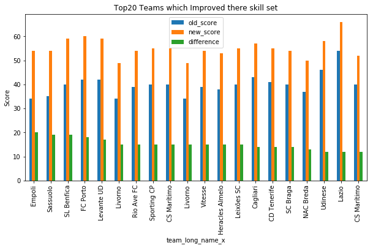

```python
improvedteams=table3[['team_long_name_x','old_score','new_score']].copy()
improvedteams['difference']=improvedteams['new_score']-improvedteams['old_score']
improvedteams.sort_values(['difference'], ascending=[False], inplace=True)
top20improvedteams=improvedteams.head(20)
top20improvedteams.plot('team_long_name_x',kind='bar',figsize=(10,5));
plt.title('Top20 Teams which Improved there skill set');
plt.ylabel('Score');
#Below Graph is showing the top20 teams that have improved from 2010 to 2016.
```

Above Graph represent the teams which have improved there skill set in the last 6 years. Graph shows that team on the most left has improved most and as we move down to right, the improvement is decending. We have taken top 20 teams, put there old score and new score to show how much they have improved.

## Research Question 2 What team attributes lead to the most victories?

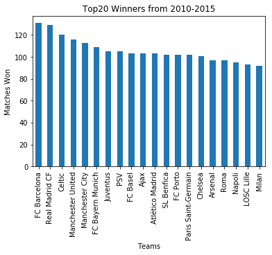

```python
# Continue to explore the data to address your additional research
#   questions. Add more headers as needed if you have more questions to
#   investigate.

match_table['goal_diff']=match_table['home_team_goal']-match_table['away_team_goal']
#match_table.groupby('home_team_api_id)['goal_diff'].sum()
match_table2=match_table[['home_team_api_id','home_team_goal','away_team_goal','goal_diff']].copy();

#sort the values in Decending order
match_table2=match_table2.sort_values('goal_diff', ascending=[False])

match_table2a=pd.merge(match_table2,team_table, left_on='home_team_api_id', right_on='team_api_id')
match_table2a
#get the winner teams
match_table2a['result'] = np.where(match_table2a['goal_diff']>0, 1, 0)
match_table2a
#match_table2.sort_values('goal_diff', ascending=[False], inplace=True, kind='quicksort')
#match_table3=match_table2.head(10)
#match_table2.sort_values('goal_diff', ascending=[False], inplace=True, kind='quicksort')
#match_table3=match_table2.head(10)

#match_table3
match_table3=match_table2a.groupby('team_long_name')['result'].sum().sort_values(ascending=False)
match_table3b=match_table3.head(20)
plt.title('Top20 Winners from 2010-2015')
match_table3b.plot(kind='bar');
plt.ylabel('Matches Won');
plt.xlabel('Teams');
#bestteams=pd.merge(bestteams,team_table,how='left',right_on='home_team_api_id')
#bestteams
```

Above Graph represent the teams which have won the most matches last 6 years. Graph shows that team on the most left (FC Barcelona) has won most. We have taken the the top20 teams. Graph shows number of matches won on the left(Y-Axis)

```python
match_table3a=pd.merge(match_table3b,team_table,how='left',left_on='team_long_name', right_on='team_long_name')
```

```python
team_att_table1a=team_att_table
team_att_table1a['date']=team_att_table['date'].str.contains('2015')
team_att_table1b=team_att_table1a.query('date==True')
team_att_table1b
```

|  | id | team_fifa_api_id | team_api_id | date | buildUpPlaySpeed | buildUpPlaySpeedClass | buildUpPlayDribbling | buildUpPlayDribblingClass | buildUpPlayPassing | buildUpPlayPassingClass | ... | chanceCreationShootingClass | chanceCreationPositioningClass | defencePressure | defencePressureClass | defenceAggression | defenceAggressionClass | defenceTeamWidth | defenceTeamWidthClass | defenceDefenderLineClass | combined_score |
| --- | --- | --- | --- | --- | --- | --- | --- | --- | --- | --- | --- | --- | --- | --- | --- | --- | --- | --- | --- | --- | --- |
| 2 | 3 | 434 | 9930 | True | 47 | Balanced | 41 | Normal | 54 | Mixed | ... | Normal | Organised | 47 | Medium | 44 | Press | 54 | Normal | Cover | 52 |
| 8 | 9 | 77 | 8485 | True | 59 | Balanced | 64 | Normal | 53 | Mixed | ... | Normal | Free Form | 49 | Medium | 45 | Press | 63 | Normal | Cover | 57 |
| 14 | 15 | 614 | 8576 | True | 59 | Balanced | 57 | Normal | 52 | Mixed | ... | Normal | Organised | 38 | Medium | 47 | Press | 53 | Normal | Cover | 49 |
| 20 | 21 | 47 | 8564 | True | 48 | Balanced | 70 | Lots | 52 | Mixed | ... | Lots | Organised | 58 | Medium | 57 | Press | 49 | Normal | Cover | 56 |
| 26 | 27 | 1901 | 10215 | True | 53 | Balanced | 53 | Normal | 44 | Mixed | ... | Normal | Organised | 39 | Medium | 38 | Press | 61 | Normal | Cover | 50 |
| 32 | 33 | 650 | 10217 | True | 56 | Balanced | 40 | Normal | 66 | Mixed | ... | Normal | Organised | 40 | Medium | 50 | Press | 52 | Normal | Cover | 49 |
| 38 | 39 | 245 | 8593 | True | 35 | Balanced | 43 | Normal | 39 | Mixed | ... | Little | Free Form | 64 | Medium | 53 | Press | 59 | Normal | Cover | 48 |
| 44 | 45 | 1861 | 9865 | True | 46 | Balanced | 41 | Normal | 65 | Mixed | ... | Normal | Organised | 37 | Medium | 53 | Press | 45 | Normal | Cover | 48 |
| 50 | 51 | 229 | 8635 | True | 52 | Balanced | 46 | Normal | 51 | Mixed | ... | Normal | Organised | 53 | Medium | 50 | Press | 61 | Normal | Cover | 52 |
| 56 | 57 | 1530 | 8121 | True | 48 | Balanced | 61 | Normal | 50 | Mixed | ... | Normal | Organised | 44 | Medium | 44 | Press | 51 | Normal | Cover | 48 |
| 64 | 65 | 111989 | 108893 | True | 56 | Balanced | 46 | Normal | 54 | Mixed | ... | Normal | Organised | 48 | Medium | 53 | Press | 57 | Normal | Cover | 50 |
| 69 | 70 | 112513 | 158085 | True | 65 | Balanced | 66 | Normal | 39 | Mixed | ... | Normal | Organised | 37 | Medium | 39 | Press | 37 | Normal | Cover | 49 |
| 75 | 76 | 1 | 9825 | True | 59 | Balanced | 51 | Normal | 30 | Short | ... | Normal | Free Form | 51 | Medium | 44 | Press | 52 | Normal | Cover | 45 |
| 81 | 82 | 2 | 10252 | True | 63 | Balanced | 37 | Normal | 54 | Mixed | ... | Normal | Organised | 35 | Medium | 44 | Press | 54 | Normal | Cover | 48 |
| 87 | 88 | 39 | 8524 | True | 64 | Balanced | 45 | Normal | 37 | Mixed | ... | Normal | Organised | 36 | Medium | 63 | Press | 49 | Normal | Cover | 48 |
| 93 | 94 | 448 | 8315 | True | 46 | Balanced | 46 | Normal | 39 | Mixed | ... | Normal | Free Form | 49 | Medium | 57 | Press | 50 | Normal | Cover | 48 |
| 99 | 100 | 240 | 9906 | True | 57 | Balanced | 50 | Normal | 50 | Mixed | ... | Normal | Organised | 49 | Medium | 42 | Press | 52 | Normal | Cover | 52 |
| 105 | 106 | 100409 | 8406 | True | 59 | Balanced | 51 | Normal | 55 | Mixed | ... | Normal | Organised | 34 | Medium | 50 | Press | 59 | Normal | Cover | 52 |
| 111 | 112 | 57 | 8583 | True | 64 | Balanced | 55 | Normal | 49 | Mixed | ... | Normal | Organised | 34 | Medium | 45 | Press | 40 | Normal | Cover | 50 |
| 117 | 118 | 1906 | 10229 | True | 50 | Balanced | 46 | Normal | 58 | Mixed | ... | Normal | Organised | 50 | Medium | 61 | Press | 55 | Normal | Cover | 54 |
| 123 | 124 | 241 | 8634 | True | 36 | Balanced | 35 | Normal | 51 | Mixed | ... | Normal | Free Form | 61 | Medium | 65 | Press | 65 | Normal | Cover | 50 |
| 129 | 130 | 1848 | 9976 | True | 52 | Balanced | 40 | Normal | 65 | Mixed | ... | Normal | Organised | 50 | Medium | 51 | Press | 55 | Normal | Cover | 50 |
| 135 | 136 | 896 | 9931 | True | 61 | Balanced | 63 | Normal | 46 | Mixed | ... | Normal | Organised | 47 | Medium | 58 | Press | 53 | Normal | Cover | 57 |
| 141 | 142 | 32 | 8178 | True | 73 | Fast | 29 | Little | 55 | Mixed | ... | Normal | Organised | 61 | Medium | 72 | Double | 50 | Normal | Cover | 59 |
| 147 | 148 | 21 | 9823 | True | 45 | Balanced | 24 | Little | 28 | Short | ... | Little | Free Form | 72 | High | 53 | Press | 59 | Normal | Cover | 41 |
| 157 | 158 | 1889 | 9807 | True | 51 | Balanced | 53 | Normal | 52 | Mixed | ... | Normal | Organised | 38 | Medium | 48 | Press | 49 | Normal | Cover | 46 |
| 165 | 166 | 234 | 9772 | True | 69 | Fast | 55 | Normal | 53 | Mixed | ... | Normal | Organised | 60 | Medium | 57 | Press | 54 | Normal | Cover | 59 |
| 171 | 172 | 88 | 8658 | True | 56 | Balanced | 32 | Little | 75 | Long | ... | Normal | Organised | 42 | Medium | 47 | Press | 54 | Normal | Cover | 56 |
| 177 | 178 | 3 | 8655 | True | 60 | Balanced | 60 | Normal | 65 | Mixed | ... | Normal | Organised | 50 | Medium | 50 | Press | 57 | Normal | Cover | 55 |
| 183 | 184 | 1926 | 8483 | True | 62 | Balanced | 36 | Normal | 64 | Mixed | ... | Normal | Organised | 39 | Medium | 38 | Press | 54 | Normal | Cover | 51 |
| ... | ... | ... | ... | ... | ... | ... | ... | ... | ... | ... | ... | ... | ... | ... | ... | ... | ... | ... | ... | ... | ... |
| 1274 | 1275 | 54 | 9804 | True | 69 | Fast | 69 | Lots | 36 | Mixed | ... | Normal | Organised | 39 | Medium | 46 | Press | 52 | Normal | Cover | 52 |
| 1280 | 1281 | 18 | 8586 | True | 47 | Balanced | 46 | Normal | 40 | Mixed | ... | Normal | Organised | 63 | Medium | 54 | Press | 56 | Normal | Cover | 50 |
| 1286 | 1287 | 1809 | 9941 | True | 49 | Balanced | 56 | Normal | 53 | Mixed | ... | Normal | Organised | 36 | Medium | 45 | Press | 49 | Normal | Cover | 45 |
| 1291 | 1292 | 294 | 10242 | True | 49 | Balanced | 48 | Normal | 51 | Mixed | ... | Normal | Organised | 43 | Medium | 42 | Press | 52 | Normal | Cover | 48 |
| 1297 | 1298 | 1908 | 8611 | True | 48 | Balanced | 40 | Normal | 43 | Mixed | ... | Normal | Organised | 44 | Medium | 41 | Press | 55 | Normal | Cover | 45 |
| 1303 | 1304 | 55 | 8600 | True | 68 | Fast | 54 | Normal | 63 | Mixed | ... | Normal | Organised | 40 | Medium | 57 | Press | 57 | Normal | Cover | 58 |
| 1312 | 1313 | 461 | 10267 | True | 35 | Balanced | 46 | Normal | 35 | Mixed | ... | Normal | Organised | 49 | Medium | 45 | Press | 53 | Normal | Cover | 45 |
| 1318 | 1319 | 110456 | 9873 | True | 49 | Balanced | 59 | Normal | 52 | Mixed | ... | Normal | Organised | 47 | Medium | 51 | Press | 46 | Normal | Cover | 53 |
| 1324 | 1325 | 462 | 10281 | True | 43 | Balanced | 40 | Normal | 65 | Mixed | ... | Normal | Organised | 47 | Medium | 40 | Press | 47 | Normal | Cover | 47 |
| 1328 | 1329 | 206 | 9876 | True | 57 | Balanced | 29 | Little | 38 | Mixed | ... | Normal | Organised | 47 | Medium | 59 | Press | 52 | Normal | Cover | 47 |
| 1334 | 1335 | 36 | 10269 | True | 59 | Balanced | 55 | Normal | 41 | Mixed | ... | Normal | Organised | 41 | Medium | 44 | Press | 32 | Narrow | Cover | 49 |
| 1340 | 1341 | 483 | 10205 | True | 48 | Balanced | 42 | Normal | 36 | Mixed | ... | Normal | Free Form | 47 | Medium | 48 | Press | 44 | Normal | Cover | 45 |
| 1346 | 1347 | 1909 | 8277 | True | 57 | Balanced | 40 | Normal | 48 | Mixed | ... | Lots | Free Form | 60 | Medium | 58 | Press | 62 | Normal | Cover | 54 |
| 1352 | 1353 | 1887 | 7844 | True | 40 | Balanced | 52 | Normal | 39 | Mixed | ... | Normal | Organised | 37 | Medium | 40 | Press | 64 | Normal | Cover | 49 |
| 1358 | 1359 | 665 | 10238 | True | 58 | Balanced | 49 | Normal | 42 | Mixed | ... | Normal | Organised | 37 | Medium | 37 | Press | 58 | Normal | Cover | 48 |
| 1365 | 1366 | 110913 | 8475 | True | 38 | Balanced | 45 | Normal | 49 | Mixed | ... | Normal | Organised | 27 | Deep | 32 | Contain | 35 | Normal | Cover | 40 |
| 1371 | 1372 | 1795 | 9817 | True | 61 | Balanced | 32 | Little | 52 | Mixed | ... | Normal | Free Form | 38 | Medium | 52 | Press | 45 | Normal | Cover | 46 |
| 1377 | 1378 | 38 | 8697 | True | 56 | Balanced | 55 | Normal | 63 | Mixed | ... | Normal | Organised | 63 | Medium | 47 | Press | 73 | Wide | Cover | 61 |
| 1383 | 1384 | 109 | 8659 | True | 62 | Balanced | 32 | Little | 51 | Mixed | ... | Normal | Organised | 41 | Medium | 40 | Press | 49 | Normal | Cover | 48 |
| 1389 | 1390 | 19 | 8654 | True | 77 | Fast | 37 | Normal | 57 | Mixed | ... | Little | Organised | 30 | Deep | 37 | Press | 41 | Normal | Cover | 49 |
| 1393 | 1394 | 681 | 10001 | True | 52 | Balanced | 46 | Normal | 50 | Mixed | ... | Little | Organised | 48 | Medium | 45 | Press | 53 | Normal | Cover | 48 |
| 1403 | 1404 | 1917 | 8528 | True | 51 | Balanced | 37 | Normal | 56 | Mixed | ... | Normal | Organised | 62 | Medium | 48 | Press | 44 | Normal | Cover | 49 |
| 1407 | 1408 | 1907 | 8525 | True | 51 | Balanced | 36 | Normal | 63 | Mixed | ... | Normal | Organised | 43 | Medium | 45 | Press | 47 | Normal | Cover | 48 |
| 1413 | 1414 | 1873 | 10265 | True | 33 | Slow | 49 | Normal | 37 | Mixed | ... | Little | Free Form | 62 | Medium | 58 | Press | 37 | Normal | Cover | 41 |
| 1419 | 1420 | 175 | 8721 | True | 68 | Fast | 45 | Normal | 57 | Mixed | ... | Normal | Organised | 66 | Medium | 46 | Press | 55 | Normal | Cover | 58 |
| 1425 | 1426 | 110 | 8602 | True | 46 | Balanced | 36 | Normal | 54 | Mixed | ... | Normal | Organised | 47 | Medium | 48 | Press | 55 | Normal | Cover | 48 |
| 1438 | 1439 | 900 | 10192 | True | 52 | Balanced | 56 | Normal | 64 | Mixed | ... | Normal | Organised | 44 | Medium | 34 | Press | 50 | Normal | Cover | 50 |
| 1449 | 1450 | 244 | 8394 | True | 52 | Balanced | 52 | Normal | 50 | Mixed | ... | Normal | Organised | 48 | Medium | 43 | Press | 49 | Normal | Cover | 51 |
| 1451 | 1452 | 112512 | 8027 | True | 54 | Balanced | 51 | Normal | 40 | Mixed | ... | Normal | Organised | 44 | Medium | 47 | Press | 52 | Normal | Cover | 48 |
| 1457 | 1458 | 15005 | 10000 | True | 54 | Balanced | 42 | Normal | 51 | Mixed | ... | Little | Organised | 44 | Medium | 58 | Press | 37 | Normal | Cover | 46 |

245 rows × 26 columns

```python
match_table3c=pd.merge(match_table3a,team_att_table1b,how='outer',left_on='team_api_id', right_on='team_api_id')
```

```python
match_table3c.dropna(inplace=True) # dropping the rows with missing data
columns=['team_api_id','team_fifa_api_id_x','team_short_name','team_fifa_api_id_y']# dropping extra columns from the table
match_table3c = match_table3c.drop(columns,axis=1)
match_table3c
```

|  | team_long_name | result | id_x | id_y | date | buildUpPlaySpeed | buildUpPlaySpeedClass | buildUpPlayDribbling | buildUpPlayDribblingClass | buildUpPlayPassing | ... | chanceCreationShootingClass | chanceCreationPositioningClass | defencePressure | defencePressureClass | defenceAggression | defenceAggressionClass | defenceTeamWidth | defenceTeamWidthClass | defenceDefenderLineClass | combined_score |
| --- | --- | --- | --- | --- | --- | --- | --- | --- | --- | --- | --- | --- | --- | --- | --- | --- | --- | --- | --- | --- | --- |
| 0 | FC Barcelona | 131.0 | 43042.0 | 124 | True | 36 | Balanced | 35 | Normal | 51 | ... | Normal | Free Form | 61 | Medium | 65 | Press | 65 | Normal | Cover | 50 |
| 1 | Real Madrid CF | 129.0 | 43040.0 | 1054 | True | 50 | Balanced | 57 | Normal | 46 | ... | Normal | Free Form | 52 | Medium | 60 | Press | 63 | Normal | Cover | 54 |
| 2 | Celtic | 120.0 | 39395.0 | 294 | True | 54 | Balanced | 49 | Normal | 53 | ... | Normal | Organised | 58 | Medium | 55 | Press | 56 | Normal | Cover | 54 |
| 3 | Manchester United | 116.0 | 3457.0 | 812 | True | 38 | Balanced | 42 | Normal | 44 | ... | Normal | Organised | 54 | Medium | 53 | Press | 56 | Normal | Cover | 46 |
| 4 | Manchester City | 113.0 | 3466.0 | 806 | True | 59 | Balanced | 35 | Normal | 29 | ... | Little | Free Form | 48 | Medium | 47 | Press | 54 | Normal | Cover | 41 |
| 5 | FC Bayern Munich | 109.0 | 15617.0 | 148 | True | 45 | Balanced | 24 | Little | 28 | ... | Little | Free Form | 72 | High | 53 | Press | 59 | Normal | Cover | 41 |
| 6 | Juventus | 105.0 | 20522.0 | 630 | True | 50 | Balanced | 35 | Normal | 20 | ... | Lots | Organised | 35 | Medium | 65 | Press | 35 | Normal | Cover | 48 |
| 7 | PSV | 105.0 | 26556.0 | 1013 | True | 67 | Fast | 43 | Normal | 43 | ... | Little | Organised | 40 | Medium | 40 | Press | 48 | Normal | Cover | 45 |
| 8 | FC Basel | 103.0 | 49118.0 | 136 | True | 61 | Balanced | 63 | Normal | 46 | ... | Normal | Organised | 47 | Medium | 58 | Press | 53 | Normal | Cover | 57 |
| 9 | Ajax | 103.0 | 26552.0 | 39 | True | 35 | Balanced | 43 | Normal | 39 | ... | Little | Free Form | 64 | Medium | 53 | Press | 59 | Normal | Cover | 48 |
| 10 | Atlético Madrid | 103.0 | 43053.0 | 100 | True | 57 | Balanced | 50 | Normal | 50 | ... | Normal | Organised | 49 | Medium | 42 | Press | 52 | Normal | Cover | 52 |
| 11 | SL Benfica | 102.0 | 35294.0 | 166 | True | 69 | Fast | 55 | Normal | 53 | ... | Normal | Organised | 60 | Medium | 57 | Press | 54 | Normal | Cover | 59 |
| 12 | FC Porto | 102.0 | 35283.0 | 438 | True | 70 | Fast | 50 | Normal | 53 | ... | Lots | Organised | 58 | Medium | 60 | Press | 60 | Normal | Cover | 60 |
| 13 | Paris Saint-Germain | 102.0 | 9548.0 | 967 | True | 49 | Balanced | 47 | Normal | 34 | ... | Normal | Organised | 57 | Medium | 53 | Press | 56 | Normal | Cover | 50 |
| 14 | Chelsea | 101.0 | 3475.0 | 312 | True | 67 | Fast | 41 | Normal | 36 | ... | Normal | Organised | 39 | Medium | 41 | Press | 46 | Normal | Cover | 43 |
| 15 | Arsenal | 97.0 | 3459.0 | 76 | True | 59 | Balanced | 51 | Normal | 30 | ... | Normal | Free Form | 51 | Medium | 44 | Press | 52 | Normal | Cover | 45 |
| 16 | Roma | 97.0 | 20525.0 | 1109 | True | 68 | Fast | 27 | Little | 47 | ... | Normal | Free Form | 36 | Medium | 57 | Press | 48 | Normal | Cover | 52 |
| 17 | Napoli | 95.0 | 20526.0 | 1210 | True | 53 | Balanced | 70 | Lots | 37 | ... | Lots | Organised | 47 | Medium | 57 | Press | 53 | Normal | Offside Trap | 56 |
| 18 | LOSC Lille | 93.0 | 9550.0 | 742 | True | 45 | Balanced | 36 | Normal | 43 | ... | Normal | Organised | 59 | Medium | 42 | Press | 48 | Normal | Cover | 50 |
| 19 | Milan | 92.0 | 20523.0 | 21 | True | 48 | Balanced | 70 | Lots | 52 | ... | Lots | Organised | 58 | Medium | 57 | Press | 49 | Normal | Cover | 56 |

20 rows × 27 columns

```python
columns=['id_x','id_y','date']# dropping extra columns from the table
match_table3c = match_table3c.drop(columns,axis=1)
match_table3c
```

|  | team_long_name | result | buildUpPlaySpeed | buildUpPlaySpeedClass | buildUpPlayDribbling | buildUpPlayDribblingClass | buildUpPlayPassing | buildUpPlayPassingClass | buildUpPlayPositioningClass | chanceCreationPassing | ... | chanceCreationShootingClass | chanceCreationPositioningClass | defencePressure | defencePressureClass | defenceAggression | defenceAggressionClass | defenceTeamWidth | defenceTeamWidthClass | defenceDefenderLineClass | combined_score |
| --- | --- | --- | --- | --- | --- | --- | --- | --- | --- | --- | --- | --- | --- | --- | --- | --- | --- | --- | --- | --- | --- |
| 0 | FC Barcelona | 131.0 | 36 | Balanced | 35 | Normal | 51 | Mixed | Free Form | 36 | ... | Normal | Free Form | 61 | Medium | 65 | Press | 65 | Normal | Cover | 50 |
| 1 | Real Madrid CF | 129.0 | 50 | Balanced | 57 | Normal | 46 | Mixed | Free Form | 61 | ... | Normal | Free Form | 52 | Medium | 60 | Press | 63 | Normal | Cover | 54 |
| 2 | Celtic | 120.0 | 54 | Balanced | 49 | Normal | 53 | Mixed | Organised | 51 | ... | Normal | Organised | 58 | Medium | 55 | Press | 56 | Normal | Cover | 54 |
| 3 | Manchester United | 116.0 | 38 | Balanced | 42 | Normal | 44 | Mixed | Organised | 49 | ... | Normal | Organised | 54 | Medium | 53 | Press | 56 | Normal | Cover | 46 |
| 4 | Manchester City | 113.0 | 59 | Balanced | 35 | Normal | 29 | Short | Free Form | 38 | ... | Little | Free Form | 48 | Medium | 47 | Press | 54 | Normal | Cover | 41 |
| 5 | FC Bayern Munich | 109.0 | 45 | Balanced | 24 | Little | 28 | Short | Free Form | 37 | ... | Little | Free Form | 72 | High | 53 | Press | 59 | Normal | Cover | 41 |
| 6 | Juventus | 105.0 | 50 | Balanced | 35 | Normal | 20 | Short | Organised | 65 | ... | Lots | Organised | 35 | Medium | 65 | Press | 35 | Normal | Cover | 48 |
| 7 | PSV | 105.0 | 67 | Fast | 43 | Normal | 43 | Mixed | Organised | 53 | ... | Little | Organised | 40 | Medium | 40 | Press | 48 | Normal | Cover | 45 |
| 8 | FC Basel | 103.0 | 61 | Balanced | 63 | Normal | 46 | Mixed | Organised | 66 | ... | Normal | Organised | 47 | Medium | 58 | Press | 53 | Normal | Cover | 57 |
| 9 | Ajax | 103.0 | 35 | Balanced | 43 | Normal | 39 | Mixed | Organised | 58 | ... | Little | Free Form | 64 | Medium | 53 | Press | 59 | Normal | Cover | 48 |
| 10 | Atlético Madrid | 103.0 | 57 | Balanced | 50 | Normal | 50 | Mixed | Organised | 61 | ... | Normal | Organised | 49 | Medium | 42 | Press | 52 | Normal | Cover | 52 |
| 11 | SL Benfica | 102.0 | 69 | Fast | 55 | Normal | 53 | Mixed | Organised | 65 | ... | Normal | Organised | 60 | Medium | 57 | Press | 54 | Normal | Cover | 59 |
| 12 | FC Porto | 102.0 | 70 | Fast | 50 | Normal | 53 | Mixed | Organised | 56 | ... | Lots | Organised | 58 | Medium | 60 | Press | 60 | Normal | Cover | 60 |
| 13 | Paris Saint-Germain | 102.0 | 49 | Balanced | 47 | Normal | 34 | Mixed | Organised | 62 | ... | Normal | Organised | 57 | Medium | 53 | Press | 56 | Normal | Cover | 50 |
| 14 | Chelsea | 101.0 | 67 | Fast | 41 | Normal | 36 | Mixed | Organised | 41 | ... | Normal | Organised | 39 | Medium | 41 | Press | 46 | Normal | Cover | 43 |
| 15 | Arsenal | 97.0 | 59 | Balanced | 51 | Normal | 30 | Short | Organised | 28 | ... | Normal | Free Form | 51 | Medium | 44 | Press | 52 | Normal | Cover | 45 |
| 16 | Roma | 97.0 | 68 | Fast | 27 | Little | 47 | Mixed | Organised | 71 | ... | Normal | Free Form | 36 | Medium | 57 | Press | 48 | Normal | Cover | 52 |
| 17 | Napoli | 95.0 | 53 | Balanced | 70 | Lots | 37 | Mixed | Organised | 68 | ... | Lots | Organised | 47 | Medium | 57 | Press | 53 | Normal | Offside Trap | 56 |
| 18 | LOSC Lille | 93.0 | 45 | Balanced | 36 | Normal | 43 | Mixed | Organised | 68 | ... | Normal | Organised | 59 | Medium | 42 | Press | 48 | Normal | Cover | 50 |
| 19 | Milan | 92.0 | 48 | Balanced | 70 | Lots | 52 | Mixed | Organised | 66 | ... | Lots | Organised | 58 | Medium | 57 | Press | 49 | Normal | Cover | 56 |

20 rows × 24 columns

```python
match_table3c = match_table3c.rename(columns={'result': 'wins from 2010-2015'})
```

```python
match_table3c = match_table3c.drop('wins from 2010-2015',axis=1)
```

```python
#match_table3c = match_table3c.drop('combined_score',axis=1)
```

```python
match_table3c.groupby('team_long_name').mean()
```

| team_long_name | buildUpPlaySpeed | buildUpPlayDribbling | buildUpPlayPassing | chanceCreationPassing | chanceCreationCrossing | chanceCreationShooting | defencePressure | defenceAggression | defenceTeamWidth | combined_score |
| --- | --- | --- | --- | --- | --- | --- | --- | --- | --- | --- |
| Ajax | 35 | 43 | 39 | 58 | 55 | 30 | 64 | 53 | 59 | 48 |
| Arsenal | 59 | 51 | 30 | 28 | 44 | 46 | 51 | 44 | 52 | 45 |
| Atlético Madrid | 57 | 50 | 50 | 61 | 62 | 49 | 49 | 42 | 52 | 52 |
| Celtic | 54 | 49 | 53 | 51 | 51 | 62 | 58 | 55 | 56 | 54 |
| Chelsea | 67 | 41 | 36 | 41 | 34 | 44 | 39 | 41 | 46 | 43 |
| FC Barcelona | 36 | 35 | 51 | 36 | 49 | 56 | 61 | 65 | 65 | 50 |
| FC Basel | 61 | 63 | 46 | 66 | 66 | 54 | 47 | 58 | 53 | 57 |
| FC Bayern Munich | 45 | 24 | 28 | 37 | 31 | 22 | 72 | 53 | 59 | 41 |
| FC Porto | 70 | 50 | 53 | 56 | 66 | 68 | 58 | 60 | 60 | 60 |
| Juventus | 50 | 35 | 20 | 65 | 50 | 80 | 35 | 65 | 35 | 48 |
| LOSC Lille | 45 | 36 | 43 | 68 | 52 | 64 | 59 | 42 | 48 | 50 |
| Manchester City | 59 | 35 | 29 | 38 | 36 | 24 | 48 | 47 | 54 | 41 |
| Manchester United | 38 | 42 | 44 | 49 | 44 | 40 | 54 | 53 | 56 | 46 |
| Milan | 48 | 70 | 52 | 66 | 36 | 69 | 58 | 57 | 49 | 56 |
| Napoli | 53 | 70 | 37 | 68 | 54 | 67 | 47 | 57 | 53 | 56 |
| PSV | 67 | 43 | 43 | 53 | 44 | 28 | 40 | 40 | 48 | 45 |
| Paris Saint-Germain | 49 | 47 | 34 | 62 | 61 | 35 | 57 | 53 | 56 | 50 |
| Real Madrid CF | 50 | 57 | 46 | 61 | 41 | 63 | 52 | 60 | 63 | 54 |
| Roma | 68 | 27 | 47 | 71 | 54 | 66 | 36 | 57 | 48 | 52 |
| SL Benfica | 69 | 55 | 53 | 65 | 66 | 54 | 60 | 57 | 54 | 59 |

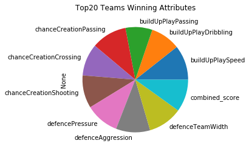

```python
match_table3d=match_table3c.mean()
match_table3d.plot('pie');
plt.title('Top20 Teams Winning Attributes');
```

Above Graph represent the skill set that is taken from top winner teams. It shows the attributes which help in making the teams winning.

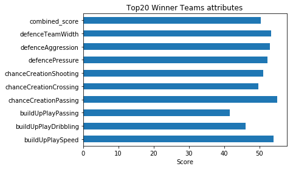

```python
#plt.title('Top20 Teams Winning Attributes')

match_table3d.plot('barh');
plt.title('Top20 Winner Teams attributes');
plt.xlabel('Score');
```

Now we are trying to findout the country and league, the winning teams belong to. we will try to find which countries have more winner teams in Europe. Lets start our analysis by finding out the countries and leagues for winning teams.

```python
match_table3e=pd.merge(match_table3c,team_table,how='left', left_on='team_long_name', right_on='team_long_name')
```

```python
match_table3f=match_table3e.drop(['buildUpPlaySpeed','buildUpPlaySpeedClass','buildUpPlayDribbling','buildUpPlayDribblingClass','buildUpPlayPassing','buildUpPlayPassingClass','buildUpPlayPositioningClass','chanceCreationPassing','chanceCreationPassingClass'],axis=1)
match_table3f=match_table3f.drop(['chanceCreationCrossing','chanceCreationCrossingClass','chanceCreationShooting','chanceCreationShootingClass','chanceCreationPositioningClass','defencePressure','defencePressureClass','defenceAggression','defenceAggressionClass','defenceTeamWidth','defenceTeamWidthClass','defenceDefenderLineClass'],axis=1)
```

```python
match_table3f
```

|  | team_long_name | combined_score | id | team_api_id | team_fifa_api_id | team_short_name |
| --- | --- | --- | --- | --- | --- | --- |
| 0 | FC Barcelona | 50 | 43042 | 8634 | 241.0 | BAR |
| 1 | Real Madrid CF | 54 | 43040 | 8633 | 243.0 | REA |
| 2 | Celtic | 54 | 39395 | 9925 | 78.0 | CEL |
| 3 | Manchester United | 46 | 3457 | 10260 | 11.0 | MUN |
| 4 | Manchester City | 41 | 3466 | 8456 | 10.0 | MCI |
| 5 | FC Bayern Munich | 41 | 15617 | 9823 | 21.0 | BMU |
| 6 | Juventus | 48 | 20522 | 9885 | 45.0 | JUV |
| 7 | PSV | 45 | 26556 | 8640 | 247.0 | PSV |
| 8 | FC Basel | 57 | 49118 | 9931 | 896.0 | BAS |
| 9 | Ajax | 48 | 26552 | 8593 | 245.0 | AJA |
| 10 | Atlético Madrid | 52 | 43053 | 9906 | 240.0 | AMA |
| 11 | SL Benfica | 59 | 35294 | 9772 | 234.0 | BEN |
| 12 | FC Porto | 60 | 35283 | 9773 | 236.0 | POR |
| 13 | Paris Saint-Germain | 50 | 9548 | 9847 | 73.0 | PSG |
| 14 | Chelsea | 43 | 3475 | 8455 | 5.0 | CHE |
| 15 | Arsenal | 45 | 3459 | 9825 | 1.0 | ARS |
| 16 | Roma | 52 | 20525 | 8686 | 52.0 | ROM |
| 17 | Napoli | 56 | 20526 | 9875 | 48.0 | NAP |
| 18 | LOSC Lille | 50 | 9550 | 8639 | 65.0 | LIL |
| 19 | Milan | 56 | 20523 | 8564 | 47.0 | ACM |

```python
match_table2e=match_table[['home_team_api_id','country_id','league_id']].copy();
```

```python
match_table2e.drop_duplicates(inplace=True)
match_table2e
```

|  | home_team_api_id | country_id | league_id |
| --- | --- | --- | --- |
| 0 | 9987 | 1 | 1 |
| 1 | 10000 | 1 | 1 |
| 2 | 9984 | 1 | 1 |
| 3 | 9991 | 1 | 1 |
| 4 | 7947 | 1 | 1 |
| 5 | 8203 | 1 | 1 |
| 6 | 9999 | 1 | 1 |
| 7 | 4049 | 1 | 1 |
| 8 | 10001 | 1 | 1 |
| 9 | 8342 | 1 | 1 |
| 10 | 9985 | 1 | 1 |
| 12 | 9994 | 1 | 1 |
| 15 | 9996 | 1 | 1 |
| 17 | 9993 | 1 | 1 |
| 18 | 8635 | 1 | 1 |
| 19 | 9998 | 1 | 1 |
| 20 | 9986 | 1 | 1 |
| 24 | 8571 | 1 | 1 |
| 315 | 9997 | 1 | 1 |
| 531 | 9989 | 1 | 1 |
| 537 | 6351 | 1 | 1 |
| 756 | 1773 | 1 | 1 |
| 1011 | 8475 | 1 | 1 |
| 1239 | 8573 | 1 | 1 |
| 1259 | 274581 | 1 | 1 |
| 1728 | 10260 | 1729 | 1729 |
| 1729 | 9825 | 1729 | 1729 |
| 1730 | 8472 | 1729 | 1729 |
| 1731 | 8654 | 1729 | 1729 |
| 1732 | 10252 | 1729 | 1729 |
| ... | ... | ... | ... |
| 21544 | 10281 | 21518 | 21518 |
| 21546 | 8479 | 21518 | 21518 |
| 21901 | 8394 | 21518 | 21518 |
| 21907 | 9867 | 21518 | 21518 |
| 21919 | 9868 | 21518 | 21518 |
| 22278 | 10278 | 21518 | 21518 |
| 22282 | 8581 | 21518 | 21518 |
| 22284 | 8560 | 21518 | 21518 |
| 22666 | 8370 | 21518 | 21518 |
| 22676 | 7878 | 21518 | 21518 |
| 23043 | 9910 | 21518 | 21518 |
| 23429 | 10268 | 21518 | 21518 |
| 23802 | 8372 | 21518 | 21518 |
| 23818 | 7869 | 21518 | 21518 |
| 24200 | 8306 | 21518 | 21518 |
| 24557 | 9956 | 24558 | 24558 |
| 24558 | 10192 | 24558 | 24558 |
| 24559 | 9930 | 24558 | 24558 |
| 24560 | 10199 | 24558 | 24558 |
| 24561 | 7955 | 24558 | 24558 |
| 24562 | 6493 | 24558 | 24558 |
| 24563 | 9931 | 24558 | 24558 |
| 24564 | 10179 | 24558 | 24558 |
| 24565 | 9824 | 24558 | 24558 |
| 24566 | 10243 | 24558 | 24558 |
| 24739 | 10190 | 24558 | 24558 |
| 24918 | 10191 | 24558 | 24558 |
| 25100 | 9777 | 24558 | 24558 |
| 25105 | 7730 | 24558 | 24558 |
| 25815 | 7896 | 24558 | 24558 |

299 rows × 3 columns

```python
match_table3g=pd.merge(match_table3f,match_table2e,how='left',left_on='team_api_id', right_on='home_team_api_id')
match_table3g
#match_table3g=match_table3g.drop(['VCH', 'VCD', 'VCA', 'GBH', 'GBD', 'GBA', 'BSH', 'BSD', 'BSA'],axis=1)
#match_table3g.columns
```

|  | team_long_name | combined_score | id | team_api_id | team_fifa_api_id | team_short_name | home_team_api_id | country_id | league_id |
| --- | --- | --- | --- | --- | --- | --- | --- | --- | --- |
| 0 | FC Barcelona | 50 | 43042 | 8634 | 241.0 | BAR | 8634 | 21518 | 21518 |
| 1 | Real Madrid CF | 54 | 43040 | 8633 | 243.0 | REA | 8633 | 21518 | 21518 |
| 2 | Celtic | 54 | 39395 | 9925 | 78.0 | CEL | 9925 | 19694 | 19694 |
| 3 | Manchester United | 46 | 3457 | 10260 | 11.0 | MUN | 10260 | 1729 | 1729 |
| 4 | Manchester City | 41 | 3466 | 8456 | 10.0 | MCI | 8456 | 1729 | 1729 |
| 5 | FC Bayern Munich | 41 | 15617 | 9823 | 21.0 | BMU | 9823 | 7809 | 7809 |
| 6 | Juventus | 48 | 20522 | 9885 | 45.0 | JUV | 9885 | 10257 | 10257 |
| 7 | PSV | 45 | 26556 | 8640 | 247.0 | PSV | 8640 | 13274 | 13274 |
| 8 | FC Basel | 57 | 49118 | 9931 | 896.0 | BAS | 9931 | 24558 | 24558 |
| 9 | Ajax | 48 | 26552 | 8593 | 245.0 | AJA | 8593 | 13274 | 13274 |
| 10 | Atlético Madrid | 52 | 43053 | 9906 | 240.0 | AMA | 9906 | 21518 | 21518 |
| 11 | SL Benfica | 59 | 35294 | 9772 | 234.0 | BEN | 9772 | 17642 | 17642 |
| 12 | FC Porto | 60 | 35283 | 9773 | 236.0 | POR | 9773 | 17642 | 17642 |
| 13 | Paris Saint-Germain | 50 | 9548 | 9847 | 73.0 | PSG | 9847 | 4769 | 4769 |
| 14 | Chelsea | 43 | 3475 | 8455 | 5.0 | CHE | 8455 | 1729 | 1729 |
| 15 | Arsenal | 45 | 3459 | 9825 | 1.0 | ARS | 9825 | 1729 | 1729 |
| 16 | Roma | 52 | 20525 | 8686 | 52.0 | ROM | 8686 | 10257 | 10257 |
| 17 | Napoli | 56 | 20526 | 9875 | 48.0 | NAP | 9875 | 10257 | 10257 |
| 18 | LOSC Lille | 50 | 9550 | 8639 | 65.0 | LIL | 8639 | 4769 | 4769 |
| 19 | Milan | 56 | 20523 | 8564 | 47.0 | ACM | 8564 | 10257 | 10257 |

```python
match_table3h=pd.merge(match_table3g,league_table,how='left',left_on='country_id', right_on='id')
```

```python
match_table3h=match_table3h.rename(columns={'name': 'League'})
```

```python
match_table3h=pd.merge(match_table3h,country_table,how='left',left_on='country_id_x', right_on='id')
match_table3h=match_table3h.rename(columns={'name': 'Country'})#Rename the Column
```

```python
match_table3h.columns#see the columns to be deleted.
```

```
Index(['team_long_name', 'combined_score', 'id_x', 'team_api_id',
       'team_fifa_api_id', 'team_short_name', 'home_team_api_id',
       'country_id_x', 'league_id', 'id_y', 'country_id_y', 'League', 'id_x',
       'name_x', 'id_y', 'name_y'],
      dtype='object')
```

```python
match_table3h = match_table3h.drop(['id_x','team_api_id','team_fifa_api_id', 'team_short_name', 'home_team_api_id','country_id_x', 'league_id', 'id_y', 'country_id_y','league_id','id_y','country_id_y'],axis=1)
```

```python
match_table3i=match_table3h.drop(['name_x','combined_score'],axis=1)
match_table3j=match_table3i.rename(columns={'name_y':'Country'})
match_table3j=match_table3j.rename(columns={'team_long_name':'Team'})
```

```python
match_table3j.pivot_table(match_table3j,index=["Country","League"], aggfunc=np.sum)
```

| Country | League | Team |
| --- | --- | --- |
| England | England Premier League | Manchester UnitedManchester CityChelseaArsenal |
| France | France Ligue 1 | Paris Saint-GermainLOSC Lille |
| Germany | Germany 1. Bundesliga | FC Bayern Munich |
| Italy | Italy Serie A | JuventusRomaNapoliMilan |
| Netherlands | Netherlands Eredivisie | PSVAjax |
| Portugal | Portugal Liga ZON Sagres | SL BenficaFC Porto |
| Scotland | Scotland Premier League | Celtic |
| Spain | Spain LIGA BBVA | FC BarcelonaReal Madrid CFAtlético Madrid |
| Switzerland | Switzerland Super League | FC Basel |

## Conclusions

> **1**: The teams which have improved there skill set from 2010 till 2015 are listed in the Graph.

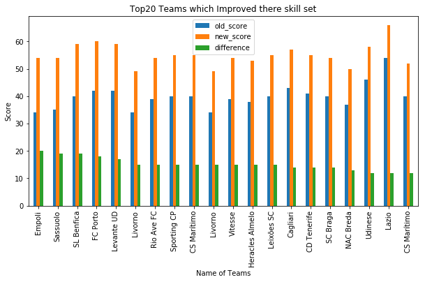

```python
top20improvedteams.plot('team_long_name_x',kind='bar',figsize=(10,5));
plt.title('Top20 Teams which Improved there skill set');
plt.ylabel('Score');
plt.xlabel('Name of Teams');
```

> **2**: If you look at the team winning attributes that we manupliated by first getting the top20 winners during the period of 2010 to 2015, we have found that chance creation passing and build up speed play is the strongest attribute to help teams winning the game.

> **3**: For Skill set, we have alot of values missing in BuilUpPlayDribbling that made our combined score a bit less accurate. Yet we get the mean value to fill up all the NaN and did analysis based on this.